# Brazilian_E_Commerce

AhmetG

2024-10-05

# Analysis in R Markdown - R Markdown’da Analiz

## Step-by-Step Process - Adım Adım Süreç

### 1. **Loading Datasets - Veri Setlerini Yükleme**

First, we will load all the datasets into the R environment.  
İlk olarak, tüm veri setlerini R ortamına yükleyeceğiz.

```r
# Loading necessary libraries - Gerekli kütüphaneleri yüklüyoruz
library(dplyr)
library(ggplot2)
```

```r
# Reading the datasets - Veri setlerini okuyoruz
order_payments <- read.csv("olist_order_payments_dataset.csv")
orders <- read.csv("olist_orders_dataset.csv")
products <- read.csv("olist_products_dataset.csv")
product_categories <- read.csv("product_category_name_translation.csv")
customers <- read.csv("olist_customers_dataset.csv")
geolocation <- read.csv("olist_geolocation_dataset.csv")
order_items <- read.csv("olist_order_items_dataset.csv")
order_reviews <- read.csv("olist_order_reviews_dataset.csv")
sellers <- read.csv("olist_sellers_dataset.csv")
```

```r
# Displaying first few rows of each dataset - Her veri setinin ilk birkaç satırını gösteriyoruz
head(order_payments)
```

```
##                           order_id payment_sequential payment_type payment_installments payment_value
## 1 b81ef226f3fe1789b1e8b2acac839d17                  1  credit_card                    8         99.33
## 2 a9810da82917af2d9aefd1278f1dcfa0                  1  credit_card                    1         24.39
## 3 25e8ea4e93396b6fa0d3dd708e76c1bd                  1  credit_card                    1         65.71
## 4 ba78997921bbcdc1373bb41e913ab953                  1  credit_card                    8        107.78
## 5 42fdf880ba16b47b59251dd489d4441a                  1  credit_card                    2        128.45
## 6 298fcdf1f73eb413e4d26d01b25bc1cd                  1  credit_card                    2         96.12
```

```r
head(orders)
```

```
##                           order_id                      customer_id order_status
## 1 e481f51cbdc54678b7cc49136f2d6af7 9ef432eb6251297304e76186b10a928d    delivered
## 2 53cdb2fc8bc7dce0b6741e2150273451 b0830fb4747a6c6d20dea0b8c802d7ef    delivered
## 3 47770eb9100c2d0c44946d9cf07ec65d 41ce2a54c0b03bf3443c3d931a367089    delivered
## 4 949d5b44dbf5de918fe9c16f97b45f8a f88197465ea7920adcdbec7375364d82    delivered
## 5 ad21c59c0840e6cb83a9ceb5573f8159 8ab97904e6daea8866dbdbc4fb7aad2c    delivered
## 6 a4591c265e18cb1dcee52889e2d8acc3 503740e9ca751ccdda7ba28e9ab8f608    delivered
##   order_purchase_timestamp   order_approved_at order_delivered_carrier_date
## 1      2017-10-02 10:56:33 2017-10-02 11:07:15          2017-10-04 19:55:00
## 2      2018-07-24 20:41:37 2018-07-26 03:24:27          2018-07-26 14:31:00
## 3      2018-08-08 08:38:49 2018-08-08 08:55:23          2018-08-08 13:50:00
## 4      2017-11-18 19:28:06 2017-11-18 19:45:59          2017-11-22 13:39:59
## 5      2018-02-13 21:18:39 2018-02-13 22:20:29          2018-02-14 19:46:34
## 6      2017-07-09 21:57:05 2017-07-09 22:10:13          2017-07-11 14:58:04
##   order_delivered_customer_date order_estimated_delivery_date
## 1           2017-10-10 21:25:13           2017-10-18 00:00:00
## 2           2018-08-07 15:27:45           2018-08-13 00:00:00
## 3           2018-08-17 18:06:29           2018-09-04 00:00:00
## 4           2017-12-02 00:28:42           2017-12-15 00:00:00
## 5           2018-02-16 18:17:02           2018-02-26 00:00:00
## 6           2017-07-26 10:57:55           2017-08-01 00:00:00
```

```r
head(products)
```

```
##                         product_id product_category_name product_name_lenght
## 1 1e9e8ef04dbcff4541ed26657ea517e5            perfumaria                  40
## 2 3aa071139cb16b67ca9e5dea641aaa2f                 artes                  44
## 3 96bd76ec8810374ed1b65e291975717f         esporte_lazer                  46
## 4 cef67bcfe19066a932b7673e239eb23d                 bebes                  27
## 5 9dc1a7de274444849c219cff195d0b71 utilidades_domesticas                  37
## 6 41d3672d4792049fa1779bb35283ed13 instrumentos_musicais                  60
##   product_description_lenght product_photos_qty product_weight_g product_length_cm product_height_cm
## 1                        287                  1              225                16                10
## 2                        276                  1             1000                30                18
## 3                        250                  1              154                18                 9
## 4                        261                  1              371                26                 4
## 5                        402                  4              625                20                17
## 6                        745                  1              200                38                 5
##   product_width_cm
## 1               14
## 2               20
## 3               15
## 4               26
## 5               13
## 6               11
```

```r
head(product_categories)
```

```
##    product_category_name product_category_name_english
## 1           beleza_saude                 health_beauty
## 2 informatica_acessorios         computers_accessories
## 3             automotivo                          auto
## 4        cama_mesa_banho                bed_bath_table
## 5       moveis_decoracao               furniture_decor
## 6          esporte_lazer                sports_leisure
```

```r
head(customers)
```

```
##                        customer_id               customer_unique_id customer_zip_code_prefix
## 1 06b8999e2fba1a1fbc88172c00ba8bc7 861eff4711a542e4b93843c6dd7febb0                    14409
## 2 18955e83d337fd6b2def6b18a428ac77 290c77bc529b7ac935b93aa66c333dc3                     9790
## 3 4e7b3e00288586ebd08712fdd0374a03 060e732b5b29e8181a18229c7b0b2b5e                     1151
## 4 b2b6027bc5c5109e529d4dc6358b12c3 259dac757896d24d7702b9acbbff3f3c                     8775
## 5 4f2d8ab171c80ec8364f7c12e35b23ad 345ecd01c38d18a9036ed96c73b8d066                    13056
## 6 879864dab9bc3047522c92c82e1212b8 4c93744516667ad3b8f1fb645a3116a4                    89254
##           customer_city customer_state
## 1                franca             SP
## 2 sao bernardo do campo             SP
## 3             sao paulo             SP
## 4       mogi das cruzes             SP
## 5              campinas             SP
## 6        jaragua do sul             SC
```

```r
head(geolocation)
```

```
##   geolocation_zip_code_prefix geolocation_lat geolocation_lng geolocation_city geolocation_state
## 1                        1037       -23.54562       -46.63929        sao paulo                SP
## 2                        1046       -23.54608       -46.64482        sao paulo                SP
## 3                        1046       -23.54613       -46.64295        sao paulo                SP
## 4                        1041       -23.54439       -46.63950        sao paulo                SP
## 5                        1035       -23.54158       -46.64161        sao paulo                SP
## 6                        1012       -23.54776       -46.63536        são paulo                SP
```

```r
head(order_items)
```

```
##                           order_id order_item_id                       product_id
## 1 00010242fe8c5a6d1ba2dd792cb16214             1 4244733e06e7ecb4970a6e2683c13e61
## 2 00018f77f2f0320c557190d7a144bdd3             1 e5f2d52b802189ee658865ca93d83a8f
## 3 000229ec398224ef6ca0657da4fc703e             1 c777355d18b72b67abbeef9df44fd0fd
## 4 00024acbcdf0a6daa1e931b038114c75             1 7634da152a4610f1595efa32f14722fc
## 5 00042b26cf59d7ce69dfabb4e55b4fd9             1 ac6c3623068f30de03045865e4e10089
## 6 00048cc3ae777c65dbb7d2a0634bc1ea             1 ef92defde845ab8450f9d70c526ef70f
##                          seller_id shipping_limit_date  price freight_value
## 1 48436dade18ac8b2bce089ec2a041202 2017-09-19 09:45:35  58.90         13.29
## 2 dd7ddc04e1b6c2c614352b383efe2d36 2017-05-03 11:05:13 239.90         19.93
## 3 5b51032eddd242adc84c38acab88f23d 2018-01-18 14:48:30 199.00         17.87
## 4 9d7a1d34a5052409006425275ba1c2b4 2018-08-15 10:10:18  12.99         12.79
## 5 df560393f3a51e74553ab94004ba5c87 2017-02-13 13:57:51 199.90         18.14
## 6 6426d21aca402a131fc0a5d0960a3c90 2017-05-23 03:55:27  21.90         12.69
```

```r
head(order_reviews)
```

```
##                          review_id                         order_id review_score review_comment_title
## 1 7bc2406110b926393aa56f80a40eba40 73fc7af87114b39712e6da79b0a377eb            4
## 2 80e641a11e56f04c1ad469d5645fdfde a548910a1c6147796b98fdf73dbeba33            5
## 3 228ce5500dc1d8e020d8d1322874b6f0 f9e4b658b201a9f2ecdecbb34bed034b            5
## 4 e64fb393e7b32834bb789ff8bb30750e 658677c97b385a9be170737859d3511b            5
## 5 f7c4243c7fe1938f181bec41a392bdeb 8e6bfb81e283fa7e4f11123a3fb894f1            5
## 6 15197aa66ff4d0650b5434f1b46cda19 b18dcdf73be66366873cd26c5724d1dc            1
##                                                                                 review_comment_message
## 1
## 2
## 3
## 4                                                                Recebi bem antes do prazo estipulado.
## 5 Parabéns lojas lannister adorei comprar pela Internet seguro e prático Parabéns a todos feliz Páscoa
## 6
##   review_creation_date review_answer_timestamp
## 1  2018-01-18 00:00:00     2018-01-18 21:46:59
## 2  2018-03-10 00:00:00     2018-03-11 03:05:13
## 3  2018-02-17 00:00:00     2018-02-18 14:36:24
## 4  2017-04-21 00:00:00     2017-04-21 22:02:06
## 5  2018-03-01 00:00:00     2018-03-02 10:26:53
## 6  2018-04-13 00:00:00     2018-04-16 00:39:37
```

```r
head(sellers)
```

```
##                          seller_id seller_zip_code_prefix       seller_city seller_state
## 1 3442f8959a84dea7ee197c632cb2df15                  13023          campinas           SP
## 2 d1b65fc7debc3361ea86b5f14c68d2e2                  13844        mogi guacu           SP
## 3 ce3ad9de960102d0677a81f5d0bb7b2d                  20031    rio de janeiro           RJ
## 4 c0f3eea2e14555b6faeea3dd58c1b1c3                   4195         sao paulo           SP
## 5 51a04a8a6bdcb23deccc82b0b80742cf                  12914 braganca paulista           SP
## 6 c240c4061717ac1806ae6ee72be3533b                  20920    rio de janeiro           RJ
```

### 2. Exploratory Data Analysis (EDA) - Keşifsel Veri Analizi (EDA)

Next, let’s explore the structure and summary of the datasets to understand them better. Sonraki adımda, veri setlerinin yapısını ve özetini inceleyelim.

```r
# Checking the structure of the 'orders' dataset - 'orders' veri setinin yapısını kontrol ediyoruz
str(orders)
```

```
## 'data.frame':    99441 obs. of  8 variables:
##  $ order_id                     : chr  "e481f51cbdc54678b7cc49136f2d6af7" "53cdb2fc8bc7dce0b6741e2150273451" "47770eb9100c2d0c44946d9cf07ec65d" "949d5b44dbf5de918fe9c16f97b45f8a" ...
##  $ customer_id                  : chr  "9ef432eb6251297304e76186b10a928d" "b0830fb4747a6c6d20dea0b8c802d7ef" "41ce2a54c0b03bf3443c3d931a367089" "f88197465ea7920adcdbec7375364d82" ...
##  $ order_status                 : chr  "delivered" "delivered" "delivered" "delivered" ...
##  $ order_purchase_timestamp     : chr  "2017-10-02 10:56:33" "2018-07-24 20:41:37" "2018-08-08 08:38:49" "2017-11-18 19:28:06" ...
##  $ order_approved_at            : chr  "2017-10-02 11:07:15" "2018-07-26 03:24:27" "2018-08-08 08:55:23" "2017-11-18 19:45:59" ...
##  $ order_delivered_carrier_date : chr  "2017-10-04 19:55:00" "2018-07-26 14:31:00" "2018-08-08 13:50:00" "2017-11-22 13:39:59" ...
##  $ order_delivered_customer_date: chr  "2017-10-10 21:25:13" "2018-08-07 15:27:45" "2018-08-17 18:06:29" "2017-12-02 00:28:42" ...
##  $ order_estimated_delivery_date: chr  "2017-10-18 00:00:00" "2018-08-13 00:00:00" "2018-09-04 00:00:00" "2017-12-15 00:00:00" ...
```

```r
# Summary statistics of 'orders' - 'orders' veri seti için özet istatistikler
summary(orders)
```

```
##    order_id         customer_id        order_status       order_purchase_timestamp order_approved_at
##  Length:99441       Length:99441       Length:99441       Length:99441             Length:99441
##  Class :character   Class :character   Class :character   Class :character         Class :character
##  Mode  :character   Mode  :character   Mode  :character   Mode  :character         Mode  :character
##  order_delivered_carrier_date order_delivered_customer_date order_estimated_delivery_date
##  Length:99441                 Length:99441                  Length:99441
##  Class :character             Class :character              Class :character
##  Mode  :character             Mode  :character              Mode  :character
```

### 3. Checking for Missing Values - Eksik Değerlerin Kontrolü

Now, we will check for any missing values in the datasets. Şimdi veri setlerindeki eksik değerleri kontrol edeceğiz.

```r
## Checking for missing values in all datasets

# Checking for missing values in the 'order_payments' dataset
sapply(order_payments, function(x) sum(is.na(x)))
```

```
##             order_id   payment_sequential         payment_type payment_installments
##                    0                    0                    0                    0
##        payment_value
##                    0
```

```r
# Checking for missing values in the 'orders' dataset
sapply(orders, function(x) sum(is.na(x)))
```

```
##                      order_id                   customer_id                  order_status
##                             0                             0                             0
##      order_purchase_timestamp             order_approved_at  order_delivered_carrier_date
##                             0                             0                             0
## order_delivered_customer_date order_estimated_delivery_date
##                             0                             0
```

```r
# Checking for missing values in the 'products' dataset
sapply(products, function(x) sum(is.na(x)))
```

```
##                 product_id      product_category_name        product_name_lenght
##                          0                          0                        610
## product_description_lenght         product_photos_qty           product_weight_g
##                        610                        610                          2
##          product_length_cm          product_height_cm           product_width_cm
##                          2                          2                          2
```

```r
# Checking for missing values in the 'product_categories' dataset
sapply(product_categories, function(x) sum(is.na(x)))
```

```
##         product_category_name product_category_name_english
##                             0                             0
```

```r
# Checking for missing values in the 'customers' dataset
sapply(customers, function(x) sum(is.na(x)))
```

```
##              customer_id       customer_unique_id customer_zip_code_prefix            customer_city
##                        0                        0                        0                        0
##           customer_state
##                        0
```

```r
# Checking for missing values in the 'geolocation' dataset
sapply(geolocation, function(x) sum(is.na(x)))
```

```
## geolocation_zip_code_prefix             geolocation_lat             geolocation_lng
##                           0                           0                           0
##            geolocation_city           geolocation_state
##                           0                           0
```

```r
# Checking for missing values in the 'order_items' dataset
sapply(order_items, function(x) sum(is.na(x)))
```

```
##            order_id       order_item_id          product_id           seller_id shipping_limit_date
##                   0                   0                   0                   0                   0
##               price       freight_value
##                   0                   0
```

```r
# Checking for missing values in the 'order_reviews' dataset
sapply(order_reviews, function(x) sum(is.na(x)))
```

```
##               review_id                order_id            review_score    review_comment_title
##                       0                       0                       0                       0
##  review_comment_message    review_creation_date review_answer_timestamp
##                       0                       0                       0
```

```r
# Checking for missing values in the 'sellers' dataset
sapply(sellers, function(x) sum(is.na(x)))
```

```
##              seller_id seller_zip_code_prefix            seller_city           seller_state
##                      0                      0                      0                      0
```

#### Eksik Değerlerin Özeti - Summary of Missing Values

- orders veri setinde eksik veri yok. There are no missing values in the orders dataset.
- order_payments veri setinde eksik veri yok. There are no missing values in the order_payments dataset.
- product_categories veri setinde eksik veri yok. There are no missing values in the product_categories dataset.
- customers veri setinde eksik veri yok. There are no missing values in the customers dataset.
- geolocation veri setinde eksik veri yok. There are no missing values in the geolocation dataset.
- order_items veri setinde eksik veri yok. There are no missing values in the order_items dataset.
- order_reviews veri setinde eksik veri yok. There are no missing values in the order_reviews dataset.
- sellers veri setinde eksik veri yok. There are no missing values in the sellers dataset.

#### Eksik Değerler Bulunan Sütunlar (products veri seti):

- product_name_lenght: 610 eksik 610 missing values in product_name_lenght
- product_description_lenght: 610 eksik 610 missing values in product_description_lenght
- product_photos_qty: 610 eksik 610 missing values in product_photos_qty
- product_weight_g: 2 eksik 2 missing values in product_weight_g
- product_length_cm: 2 eksik 2 missing values in product_length_cm
- product_height_cm: 2 eksik 2 missing values in product_height_cm
- product_width_cm: 2 eksik 2 missing values in product_width_cm

#### Ne Yapabiliriz? - What Can We Do?

Şu anda sadece **products** veri setinde eksik veriler var. Currently, there are missing values only in the **“products”** dataset. Bu verileri aşağıdaki şekilde doldurabiliriz: We can handle these missing values like that :

product_weight_g, product_length_cm, product_height_cm, product_width_cm sütunlarındaki eksik değerleri **ortalama** ile doldurabiliriz. We can fill the missing values in product_weight_g, product_length_cm, product_height_cm, and product_width_cm with the mean.

product_name_lenght, product_description_lenght, product_photos_qty sütunlarındaki eksik satırları **silebiliriz.** We can remove the rows with missing values in product_name_lenght, product_description_lenght, and product_photos_qty.

```r
# Filling missing values with the mean for numeric columns in 'products'
# Sayısal sütunlar için eksik değerleri ortalama ile dolduruyoruz
products$product_weight_g[is.na(products$product_weight_g)] <- mean(products$product_weight_g, na.rm = TRUE)
products$product_length_cm[is.na(products$product_length_cm)] <- mean(products$product_length_cm, na.rm = TRUE)
products$product_height_cm[is.na(products$product_height_cm)] <- mean(products$product_height_cm, na.rm = TRUE)
products$product_width_cm[is.na(products$product_width_cm)] <- mean(products$product_width_cm, na.rm = TRUE)

# Dropping rows with missing values for 'product_name_lenght', 'product_description_lenght', and 'product_photos_qty'
# 'product_name_lenght', 'product_description_lenght', ve 'product_photos_qty' sütunlarındaki eksik satırları siliyoruz
products <- products[!is.na(products$product_name_lenght), ]
products <- products[!is.na(products$product_description_lenght), ]
products <- products[!is.na(products$product_photos_qty), ]
```

#### Tekrar kontrol edelim eksik değer varmı. Check again for missing values

```r
# Rechecking for missing values in all datasets after cleaning

# Checking for missing values in the 'order_payments' dataset
sapply(order_payments, function(x) sum(is.na(x)))
```

```
##             order_id   payment_sequential         payment_type payment_installments
##                    0                    0                    0                    0
##        payment_value
##                    0
```

```r
# Checking for missing values in the 'orders' dataset
sapply(orders, function(x) sum(is.na(x)))
```

```
##                      order_id                   customer_id                  order_status
##                             0                             0                             0
##      order_purchase_timestamp             order_approved_at  order_delivered_carrier_date
##                             0                             0                             0
## order_delivered_customer_date order_estimated_delivery_date
##                             0                             0
```

```r
# Checking for missing values in the 'products' dataset
sapply(products, function(x) sum(is.na(x)))
```

```
##                 product_id      product_category_name        product_name_lenght
##                          0                          0                          0
## product_description_lenght         product_photos_qty           product_weight_g
##                          0                          0                          0
##          product_length_cm          product_height_cm           product_width_cm
##                          0                          0                          0
```

```r
# Checking for missing values in the 'product_categories' dataset
sapply(product_categories, function(x) sum(is.na(x)))
```

```
##         product_category_name product_category_name_english
##                             0                             0
```

```r
# Checking for missing values in the 'customers' dataset
sapply(customers, function(x) sum(is.na(x)))
```

```
##              customer_id       customer_unique_id customer_zip_code_prefix            customer_city
##                        0                        0                        0                        0
##           customer_state
##                        0
```

```r
# Checking for missing values in the 'geolocation' dataset
sapply(geolocation, function(x) sum(is.na(x)))
```

```
## geolocation_zip_code_prefix             geolocation_lat             geolocation_lng
##                           0                           0                           0
##            geolocation_city           geolocation_state
##                           0                           0
```

```r
# Checking for missing values in the 'order_items' dataset
sapply(order_items, function(x) sum(is.na(x)))
```

```
##            order_id       order_item_id          product_id           seller_id shipping_limit_date
##                   0                   0                   0                   0                   0
##               price       freight_value
##                   0                   0
```

```r
# Checking for missing values in the 'order_reviews' dataset
sapply(order_reviews, function(x) sum(is.na(x)))
```

```
##               review_id                order_id            review_score    review_comment_title
##                       0                       0                       0                       0
##  review_comment_message    review_creation_date review_answer_timestamp
##                       0                       0                       0
```

```r
# Checking for missing values in the 'sellers' dataset
sapply(sellers, function(x) sum(is.na(x)))
```

```
##              seller_id seller_zip_code_prefix            seller_city           seller_state
##                      0                      0                      0                      0
```

#### Analizimize Başlamak İçin Temel Adımlar - Fundamental Steps to Start Our Analysis

#### 1. Keşifsel Veri Analizi (EDA) - Exploratory Data Analysis (EDA)

Veri Dağılımı ve İstatistikler - Data Distribution and Statistics: Veri setinin yapısını ve genel istatistiklerini inceleyelim.

Let’s examine the structure and summary statistics of the datasets.

```r
# Structure and summary statistics of the orders dataset
# 'orders' veri setinin yapısı ve özet istatistikleri
str(orders)
```

```
## 'data.frame':    99441 obs. of  8 variables:
##  $ order_id                     : chr  "e481f51cbdc54678b7cc49136f2d6af7" "53cdb2fc8bc7dce0b6741e2150273451" "47770eb9100c2d0c44946d9cf07ec65d" "949d5b44dbf5de918fe9c16f97b45f8a" ...
##  $ customer_id                  : chr  "9ef432eb6251297304e76186b10a928d" "b0830fb4747a6c6d20dea0b8c802d7ef" "41ce2a54c0b03bf3443c3d931a367089" "f88197465ea7920adcdbec7375364d82" ...
##  $ order_status                 : chr  "delivered" "delivered" "delivered" "delivered" ...
##  $ order_purchase_timestamp     : chr  "2017-10-02 10:56:33" "2018-07-24 20:41:37" "2018-08-08 08:38:49" "2017-11-18 19:28:06" ...
##  $ order_approved_at            : chr  "2017-10-02 11:07:15" "2018-07-26 03:24:27" "2018-08-08 08:55:23" "2017-11-18 19:45:59" ...
##  $ order_delivered_carrier_date : chr  "2017-10-04 19:55:00" "2018-07-26 14:31:00" "2018-08-08 13:50:00" "2017-11-22 13:39:59" ...
##  $ order_delivered_customer_date: chr  "2017-10-10 21:25:13" "2018-08-07 15:27:45" "2018-08-17 18:06:29" "2017-12-02 00:28:42" ...
##  $ order_estimated_delivery_date: chr  "2017-10-18 00:00:00" "2018-08-13 00:00:00" "2018-09-04 00:00:00" "2017-12-15 00:00:00" ...
```

```r
summary(orders)
```

```
##    order_id         customer_id        order_status       order_purchase_timestamp order_approved_at
##  Length:99441       Length:99441       Length:99441       Length:99441             Length:99441
##  Class :character   Class :character   Class :character   Class :character         Class :character
##  Mode  :character   Mode  :character   Mode  :character   Mode  :character         Mode  :character
##  order_delivered_carrier_date order_delivered_customer_date order_estimated_delivery_date
##  Length:99441                 Length:99441                  Length:99441
##  Class :character             Class :character              Class :character
##  Mode  :character             Mode  :character              Mode  :character
```

```r
# Structure and summary statistics of the products dataset
# 'products' veri setinin yapısı ve özet istatistikleri
str(products)
```

```
## 'data.frame':    32341 obs. of  9 variables:
##  $ product_id                : chr  "1e9e8ef04dbcff4541ed26657ea517e5" "3aa071139cb16b67ca9e5dea641aaa2f" "96bd76ec8810374ed1b65e291975717f" "cef67bcfe19066a932b7673e239eb23d" ...
##  $ product_category_name     : chr  "perfumaria" "artes" "esporte_lazer" "bebes" ...
##  $ product_name_lenght       : int  40 44 46 27 37 60 56 56 57 36 ...
##  $ product_description_lenght: int  287 276 250 261 402 745 1272 184 163 1156 ...
##  $ product_photos_qty        : int  1 1 1 1 4 1 4 2 1 1 ...
##  $ product_weight_g          : num  225 1000 154 371 625 ...
##  $ product_length_cm         : num  16 30 18 26 20 38 70 40 27 17 ...
##  $ product_height_cm         : num  10 18 9 4 17 5 24 8 13 10 ...
##  $ product_width_cm          : num  14 20 15 26 13 11 44 40 17 12 ...
```

```r
summary(products)
```

```
##   product_id        product_category_name product_name_lenght product_description_lenght
##  Length:32341       Length:32341          Min.   : 5.00       Min.   :   4.0
##  Class :character   Class :character      1st Qu.:42.00       1st Qu.: 339.0
##  Mode  :character   Mode  :character      Median :51.00       Median : 595.0
##                                           Mean   :48.48       Mean   : 771.5
##                                           3rd Qu.:57.00       3rd Qu.: 972.0
##                                           Max.   :76.00       Max.   :3992.0
##  product_photos_qty product_weight_g product_length_cm product_height_cm product_width_cm
##  Min.   : 1.000     Min.   :    0    Min.   :  7.00    Min.   :  2.00    Min.   :  6.00
##  1st Qu.: 1.000     1st Qu.:  300    1st Qu.: 18.00    1st Qu.:  8.00    1st Qu.: 15.00
##  Median : 1.000     Median :  700    Median : 25.00    Median : 13.00    Median : 20.00
##  Mean   : 2.189     Mean   : 2277    Mean   : 30.85    Mean   : 16.96    Mean   : 23.21
##  3rd Qu.: 3.000     3rd Qu.: 1900    3rd Qu.: 38.00    3rd Qu.: 21.00    3rd Qu.: 30.00
##  Max.   :20.000     Max.   :40425    Max.   :105.00    Max.   :105.00    Max.   :118.00
```

#### Ödeme Türlerinin Dağılımı - Payment Method Distribution:

Ödeme yöntemlerine göre sipariş dağılımını görselleştirelim. Let’s visualize the distribution of orders by payment method.

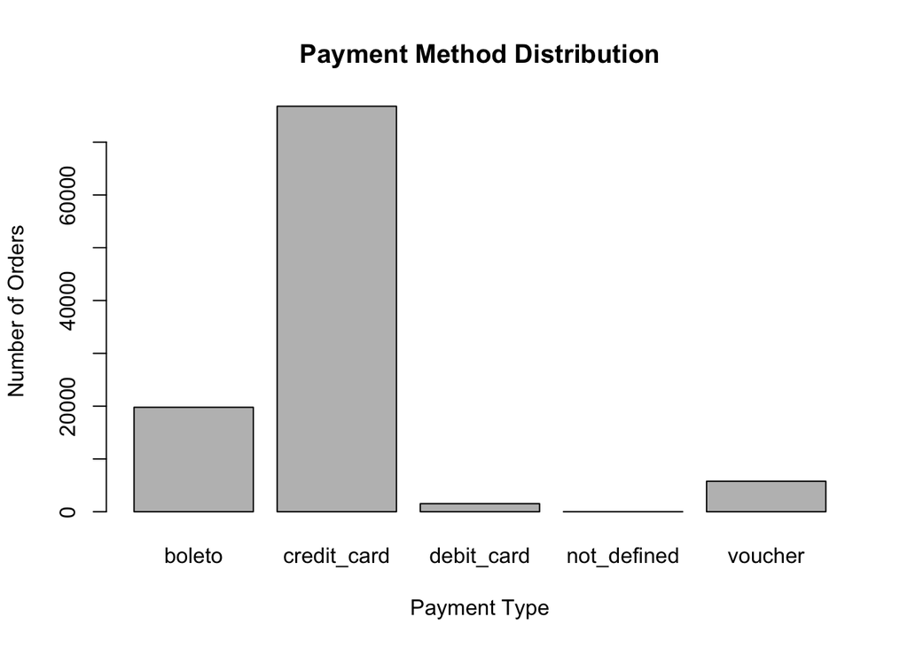

```r
# Payment method distribution
# Ödeme yöntemi dağılımı
payment_method_counts <- table(order_payments$payment_type)
barplot(payment_method_counts, main='Payment Method Distribution', xlab='Payment Type', ylab='Number of Orders')
```

#### Siparişlerin Zaman İçinde Dağılımı - Order Trend Over Time:

Siparişlerin aylara göre nasıl değiştiğini inceleyelim. Let’s examine how orders change by month.

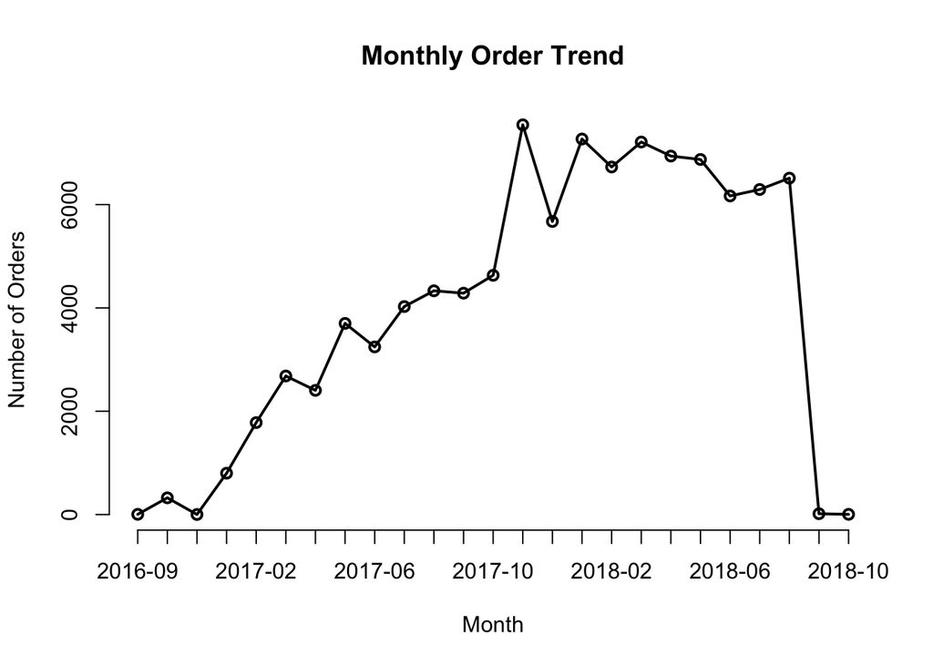

```r
# Convert 'order_purchase_timestamp' to Date format
# 'order_purchase_timestamp' tarih formatına çeviriyoruz
orders$order_purchase_timestamp <- as.Date(orders$order_purchase_timestamp)

# Group orders by month and count them
# Siparişleri ay bazında gruplayıp sayıyoruz
monthly_orders <- table(format(orders$order_purchase_timestamp, "%Y-%m"))

# Plotting the monthly order trend
# Aylık sipariş trendini çiziyoruz
plot(monthly_orders, type='o', main='Monthly Order Trend', xlab='Month', ylab='Number of Orders')
```

#### 2. A/B Testi Senaryosu - A/B Testing Scenario

A/B testini uygulamak için hangi iki grup arasında karşılaştırma yapacağımıza karar verelim. Let’s decide which two groups we will compare for the A/B test.

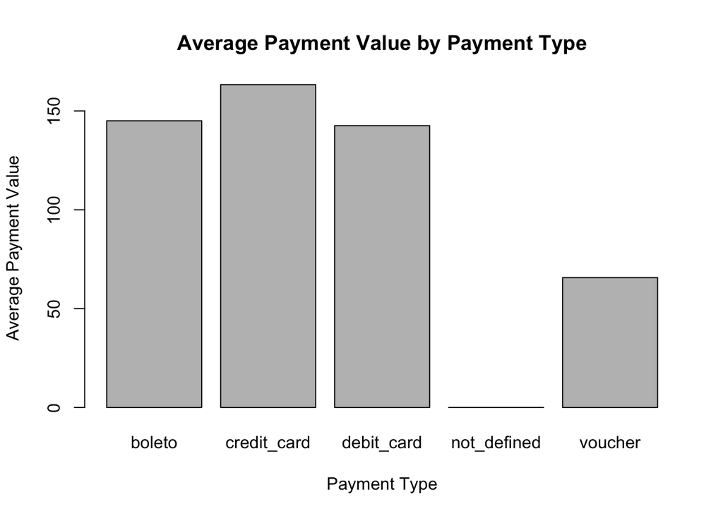

```r
# Average payment value by payment type
# Ödeme türüne göre ortalama ödeme değerini hesaplıyoruz
average_payment_value <- aggregate(payment_value ~ payment_type, data=order_payments, FUN=mean)

# Barplot for average payment value
# Ortalama ödeme değerini gösteren çubuk grafiği
barplot(average_payment_value$payment_value, names.arg=average_payment_value$payment_type, main='Average Payment Value by Payment Type', xlab='Payment Type', ylab='Average Payment Value')
```

#### Devam Edelim! - Let’s Proceed!

Bu adımları uygulayarak analizimize başlayabiliriz. We can start our analysis by applying these steps.

### 1. Veri Dağılımı ve İstatistikler - Data Distribution and Statistics

#### A) Orders Veri Setinin Yapısı ve Özet İstatistikleri - Structure and Summary Statistics of Orders Dataset

```r
# Structure and summary statistics of the orders dataset
# 'orders' veri setinin yapısı ve özet istatistikleri
str(orders)
```

```
## 'data.frame':    99441 obs. of  8 variables:
##  $ order_id                     : chr  "e481f51cbdc54678b7cc49136f2d6af7" "53cdb2fc8bc7dce0b6741e2150273451" "47770eb9100c2d0c44946d9cf07ec65d" "949d5b44dbf5de918fe9c16f97b45f8a" ...
##  $ customer_id                  : chr  "9ef432eb6251297304e76186b10a928d" "b0830fb4747a6c6d20dea0b8c802d7ef" "41ce2a54c0b03bf3443c3d931a367089" "f88197465ea7920adcdbec7375364d82" ...
##  $ order_status                 : chr  "delivered" "delivered" "delivered" "delivered" ...
##  $ order_purchase_timestamp     : Date, format: "2017-10-02" "2018-07-24" "2018-08-08" ...
##  $ order_approved_at            : chr  "2017-10-02 11:07:15" "2018-07-26 03:24:27" "2018-08-08 08:55:23" "2017-11-18 19:45:59" ...
##  $ order_delivered_carrier_date : chr  "2017-10-04 19:55:00" "2018-07-26 14:31:00" "2018-08-08 13:50:00" "2017-11-22 13:39:59" ...
##  $ order_delivered_customer_date: chr  "2017-10-10 21:25:13" "2018-08-07 15:27:45" "2018-08-17 18:06:29" "2017-12-02 00:28:42" ...
##  $ order_estimated_delivery_date: chr  "2017-10-18 00:00:00" "2018-08-13 00:00:00" "2018-09-04 00:00:00" "2017-12-15 00:00:00" ...
```

```r
summary(orders)
```

```
##    order_id         customer_id        order_status       order_purchase_timestamp order_approved_at
##  Length:99441       Length:99441       Length:99441       Min.   :2016-09-04       Length:99441
##  Class :character   Class :character   Class :character   1st Qu.:2017-09-12       Class :character
##  Mode  :character   Mode  :character   Mode  :character   Median :2018-01-18       Mode  :character
##                                                           Mean   :2017-12-30
##                                                           3rd Qu.:2018-05-04
##                                                           Max.   :2018-10-17
##  order_delivered_carrier_date order_delivered_customer_date order_estimated_delivery_date
##  Length:99441                 Length:99441                  Length:99441
##  Class :character             Class :character              Class :character
##  Mode  :character             Mode  :character              Mode  :character
##
##
##
```

#### B) Products Veri Setinin Yapısı ve Özet İstatistikleri - Structure and Summary Statistics of Products Dataset

```r
# Structure and summary statistics of the products dataset
# 'products' veri setinin yapısı ve özet istatistikleri
str(products)
```

```
## 'data.frame':    32341 obs. of  9 variables:
##  $ product_id                : chr  "1e9e8ef04dbcff4541ed26657ea517e5" "3aa071139cb16b67ca9e5dea641aaa2f" "96bd76ec8810374ed1b65e291975717f" "cef67bcfe19066a932b7673e239eb23d" ...
##  $ product_category_name     : chr  "perfumaria" "artes" "esporte_lazer" "bebes" ...
##  $ product_name_lenght       : int  40 44 46 27 37 60 56 56 57 36 ...
##  $ product_description_lenght: int  287 276 250 261 402 745 1272 184 163 1156 ...
##  $ product_photos_qty        : int  1 1 1 1 4 1 4 2 1 1 ...
##  $ product_weight_g          : num  225 1000 154 371 625 ...
##  $ product_length_cm         : num  16 30 18 26 20 38 70 40 27 17 ...
##  $ product_height_cm         : num  10 18 9 4 17 5 24 8 13 10 ...
##  $ product_width_cm          : num  14 20 15 26 13 11 44 40 17 12 ...
```

```r
summary(products)
```

```
##   product_id        product_category_name product_name_lenght product_description_lenght
##  Length:32341       Length:32341          Min.   : 5.00       Min.   :   4.0
##  Class :character   Class :character      1st Qu.:42.00       1st Qu.: 339.0
##  Mode  :character   Mode  :character      Median :51.00       Median : 595.0
##                                           Mean   :48.48       Mean   : 771.5
##                                           3rd Qu.:57.00       3rd Qu.: 972.0
##                                           Max.   :76.00       Max.   :3992.0
##  product_photos_qty product_weight_g product_length_cm product_height_cm product_width_cm
##  Min.   : 1.000     Min.   :    0    Min.   :  7.00    Min.   :  2.00    Min.   :  6.00
##  1st Qu.: 1.000     1st Qu.:  300    1st Qu.: 18.00    1st Qu.:  8.00    1st Qu.: 15.00
##  Median : 1.000     Median :  700    Median : 25.00    Median : 13.00    Median : 20.00
##  Mean   : 2.189     Mean   : 2277    Mean   : 30.85    Mean   : 16.96    Mean   : 23.21
##  3rd Qu.: 3.000     3rd Qu.: 1900    3rd Qu.: 38.00    3rd Qu.: 21.00    3rd Qu.: 30.00
##  Max.   :20.000     Max.   :40425    Max.   :105.00    Max.   :105.00    Max.   :118.00
```

### 2. Ödeme Türlerinin Dağılımı - Payment Method Distribution

Ödeme türlerini inceleyip görselleştirmek için aşağıdaki kodu kullanabilirsiniz: You can use the following code to examine and visualize the distribution of payment types.

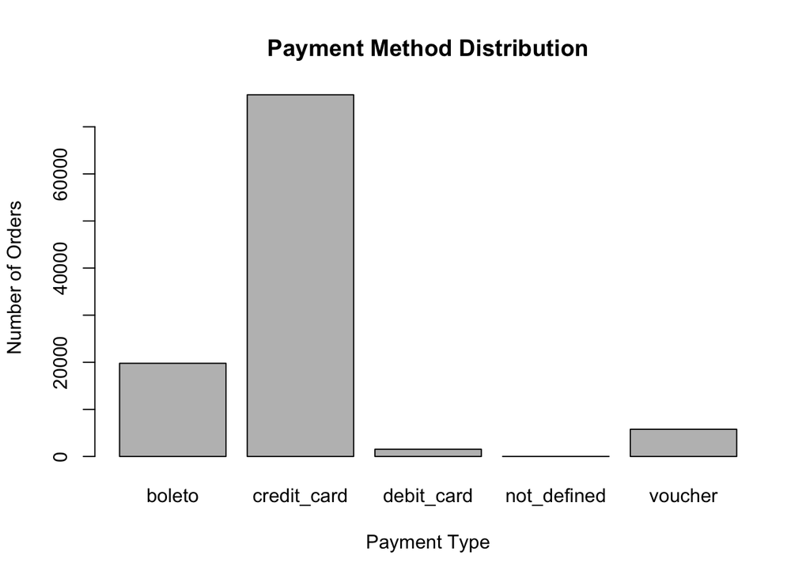

```r
# Payment method distribution
# Ödeme yöntemi dağılımı
payment_method_counts <- table(order_payments$payment_type)
barplot(payment_method_counts, main='Payment Method Distribution', xlab='Payment Type', ylab='Number of Orders')
```

### 3. Siparişlerin Zaman İçinde Dağılımı - Order Trend Over Time

Siparişlerin aylara göre nasıl değiştiğini incelemek için aşağıdaki kodu kullanabilirsiniz: You can use the following code to examine how orders vary by month.

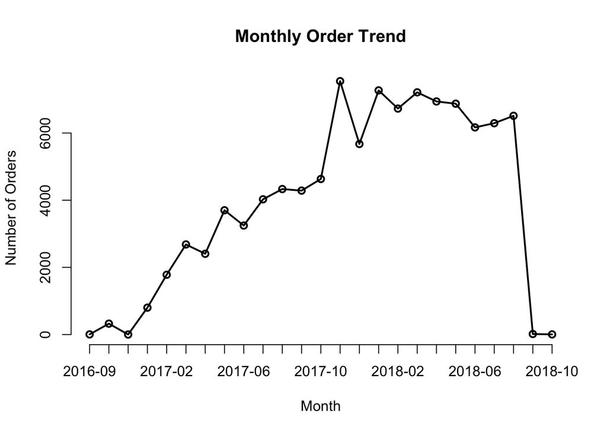

```r
# Convert 'order_purchase_timestamp' to Date format
# 'order_purchase_timestamp' tarih formatına çeviriyoruz
orders$order_purchase_timestamp <- as.Date(orders$order_purchase_timestamp)

# Group orders by month and count them
# Siparişleri ay bazında gruplayıp sayıyoruz
monthly_orders <- table(format(orders$order_purchase_timestamp, "%Y-%m"))

# Plotting the monthly order trend
# Aylık sipariş trendini çiziyoruz
plot(monthly_orders, type='o', main='Monthly Order Trend', xlab='Month', ylab='Number of Orders')
```

### 4. Analiz Sonuçları - Analysis Results

#### A) Ödeme Türlerinin Dağılımı - Distribution of Payment Methods

Ödeme türlerinin dağılımını inceledikten sonra hangi ödeme yönteminin daha fazla tercih edildiğini gözlemleyelim. After examining the distribution of payment methods, let’s observe which payment method was preferred the most.

#### B) Siparişlerin Zaman İçindeki Değişimi - Change in Orders Over Time

Siparişlerin zaman içindeki değişimini inceledikten sonra hangi aylarda daha fazla sipariş alındığını analiz edelim. After analyzing the change in orders over time, let’s analyze which months had the highest number of orders.

### 5. A/B Testi Senaryosu - A/B Testing Scenario

#### A) Ödeme Yöntemlerinin Karşılaştırılması - Comparison of Payment Methods

Şimdi A/B testini uygulamak için ödeme yöntemleri arasındaki farkları inceleyelim. Hangi ödeme yönteminin daha fazla ortalama değer getirdiğini belirlemek için aşağıdaki kodları kullanabiliriz: Now, let’s perform the A/B test by examining the differences between payment methods. We can use the following code to determine which payment method has a higher average value.

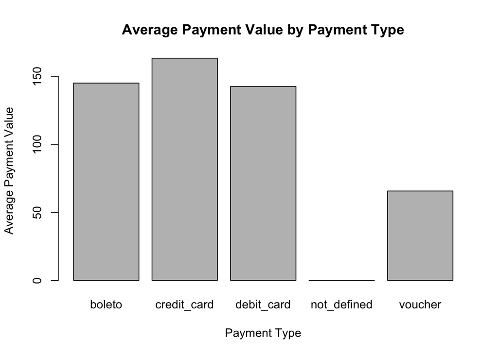

```r
# Average payment value by payment type
# Ödeme türüne göre ortalama ödeme değerini hesaplıyoruz
average_payment_value <- aggregate(payment_value ~ payment_type, data=order_payments, FUN=mean)

# Barplot for average payment value
# Ortalama ödeme değerini gösteren çubuk grafiği
barplot(average_payment_value$payment_value, names.arg=average_payment_value$payment_type, main='Average Payment Value by Payment Type', xlab='Payment Type', ylab='Average Payment Value')
```

### A/B Testi İstatistiksel Anlamlılık - A/B Test Statistical Significance

Ortalama ödeme değerleri arasındaki farkın istatistiksel olarak anlamlı olup olmadığını test etmek için bir t-test yapabiliriz. We can perform a t-test to check if the difference in average payment values is statistically significant.

```r
# Subsetting the payment data for two payment types
# İki ödeme yöntemi için ödeme verilerini alt kümelere ayırıyoruz
payment_type_1 <- subset(order_payments, payment_type == "credit_card")$payment_value
payment_type_2 <- subset(order_payments, payment_type == "boleto")$payment_value

# Performing the t-test
# T-test uyguluyoruz
t_test_result <- t.test(payment_type_1, payment_type_2)

# Displaying the t-test result
# T-test sonucunu görüntülüyoruz
print(t_test_result)
```

```
##
##  Welch Two Sample t-test
##
## data:  payment_type_1 and payment_type_2
## t = 10.649, df = 31709, p-value < 2.2e-16
## alternative hypothesis: true difference in means is not equal to 0
## 95 percent confidence interval:
##  14.91914 21.65003
## sample estimates:
## mean of x mean of y
##  163.3190  145.0344
```

### T-Test Sonuçlarını İnceleme - Reviewing T-Test Results

#### Sonuçların Yorumu - Interpretation of Results:

#### t-değeri (t-value): **10.649**

Bu, iki grup arasındaki farkın büyüklüğünü ölçen bir değerdir. Ne kadar büyükse, fark o kadar anlamlıdır. The t-value of 10.649 indicates the magnitude of the difference between the two groups. The larger the value, the more significant the difference.

#### p-değeri (p-value): **2.2e-16**’den küçük

Bu, istatistiksel anlamlılığı belirleyen önemli bir değerdir. Eğer p-değeri 0.05’ten küçükse, farkın şans eseri oluşmadığı ve istatistiksel olarak anlamlı olduğu kabul edilir. Burada p-değeri 0.05’ten çok daha küçük, yani fark istatistiksel olarak anlamlı. The p-value is less than 2.2e-16, which is well below 0.05. This means the difference between the two payment methods is statistically significant.

#### Güven Aralığı (Confidence Interval): **14.92 ile 21.65**

Bu aralık, iki grup arasındaki farkın **%95** güvenle bu değerler arasında olduğunu gösterir. The confidence interval between 14.92 and 21.65 indicates that we can be 95% confident that the true difference between the means lies within this range.

#### Ortalama Değerler (Mean Estimates):

credit_card (x): 163.32 boleto (y): 145.03 credit_card ile yapılan ödemelerin ortalama değeri boleto ile yapılan ödemelerden daha yüksek. The mean for credit_card payments is 163.32, which is higher than the mean for boleto payments (145.03).

#### Sonuç - Conclusion

Bu t-test sonuçlarına göre, **credit_card ve boleto ödeme yöntemleri arasındaki ortalama ödeme değerleri arasında istatistiksel olarak anlamlı bir fark var.** credit_card ile yapılan ödemeler ortalama olarak daha yüksek.

The results of this t-test show that there is a statistically significant difference between the average payment values for credit_card and boleto. Payments made via credit_card are on average higher.

##### **(Yukarıda açıkladığımız sonuca göre, farklı ödeme yöntemleri üzerine yapacağınız kampanyalar veya analizler için stratejiler geliştirebiliriz.Based on the results we explained above, we can develop strategies for your campaigns or analyses on different payment methods.)**

### Sonuçlara Dayalı Stratejiler - Strategies Based on Results

#### A) Ödeme Yöntemlerine Göre Farklı Stratejiler - Different Strategies Based on Payment Methods

Test sonuçlarına göre, credit_card ödeme yöntemi ortalama olarak boleto yönteminden daha yüksek bir ödeme değeri getiriyor. Bu fark üzerine şu stratejileri düşünebiliriz:

- Credit Card Kampanyaları - Credit Card Campaigns:
- Müşterileri credit_card ödeme yöntemine teşvik edecek kampanyalar düzenlenebilir. Campaigns can be created to encourage customers to use credit_card as a payment method.
- Örneğin, kredi kartı ile yapılan ödemelerde indirim veya taksit seçenekleri sunulabilir. For example, discounts or installment options could be offered for payments made via credit card.
- Boleto Ödeme Yöntemi İçin Teşvikler - Incentives for Boleto Payments:
- Boleto ödeme yöntemini tercih eden müşterilere özel teşvikler sunulabilir. Special incentives could be offered to customers who choose the boleto payment method. -Örneğin, boleto ile yapılan ödemeler için ek indirim veya bonus puanlar verilebilir. For example, extra discounts or bonus points could be offered for payments made via boleto.

#### B) Güven Aralığı ve Anlamlılık Üzerinden Yorumlama - Interpretation Based on Confidence Interval and Significance

Güven aralığı ve p-değeri sonuçlarına göre, ödeme yöntemleri arasında anlamlı bir fark var. Bu durum şu şekilde değerlendirilebilir:

- Kredi kartı ile yapılan ödemelerin getirdiği gelir daha yüksek olduğundan, bu yöntemi teşvik eden pazarlama stratejileri geliştirilebilir. Since credit card payments generate higher revenue, marketing strategies that encourage this payment method can be developed.

### Analizin Diğer Boyutları - Further Dimensions of Analysis

Bu noktada, analizimizi farklı boyutlara taşıyabiliriz. İşte birkaç öneri:

- **Zaman Serisi Analizi - Time Series Analysis:** Siparişlerin zaman içinde nasıl değiştiğini incelemek için zaman serisi analizi yapabiliriz. We can perform a time series analysis to examine how orders change over time.
- **Müşteri Segmentasyonu - Customer Segmentation:** Müşterileri demografik özelliklerine veya ödeme alışkanlıklarına göre segmentlere ayırabiliriz. We can segment customers based on demographics or payment habits.

#### Şimdi zaman serisi analizine geçelim. Zaman serisi analizi, siparişlerin veya ödemelerin zaman içindeki değişimlerini incelemek için mükemmel bir yöntemdir.

Now let’s move on to time series analysis. Time series analysis is an excellent method for examining changes in orders or payments over time.

### Zaman Serisi Analizine Başlama - Starting Time Series Analysis

Zaman serisi analizinde ilk adım, tarih sütunlarını kullanarak verileri zaman dilimlerine (gün, ay, yıl) göre gruplamak ve bu değişiklikleri incelemektir. The first step in time series analysis is to group the data by time periods (day, month, year) using date columns and examine these changes.

#### A) Siparişlerin Aylık Dağılımı - Monthly Distribution of Orders

Bu adımda siparişlerin zaman içindeki değişimini inceleyerek aylık sipariş sayısını analiz edeceğiz. In this step, we will analyze the number of monthly orders by examining the change in orders over time.

#### - Tarih Formatının Kontrolü - Checking Date Format

Öncelikle, tarih formatında bir hata olup olmadığını kontrol edelim. Bazı tarih değerleri boş olabilir ya da hatalı formatlanmış olabilir. Bu nedenle tarih sütununda NA veya eksik değerleri kontrol edelim: First, let’s check if there is an error in the date format. Some date values may be empty or formatted incorrectly. So let’s check for NA or missing values in the date column:

```r
# Check for missing or NA values in 'order_purchase_timestamp'
# 'order_purchase_timestamp' sütununda eksik veya NA değerlerini kontrol ediyoruz
sum(is.na(orders$order_purchase_timestamp))
```

```
## [1] 0
```

#### - Tarih Formatına Çevirme - Converting to Date Format

Tarih sütununu doğru formatta olduğundan emin olmak için yeniden tarih formatına çevirelim: Let’s convert the date column back to date format to make sure it’s in the correct format:

```r
# Ensure the 'order_purchase_timestamp' column is in Date format
# 'order_purchase_timestamp' sütununu doğru tarih formatına çeviriyoruz
orders$order_purchase_timestamp <- as.Date(orders$order_purchase_timestamp, format="%Y-%m-%d")
```

```r
# Checking the structure and summary of the 'order_purchase_timestamp' column
# 'order_purchase_timestamp' sütununun yapısını ve özetini kontrol edelim
str(orders$order_purchase_timestamp)
```

```
##  Date[1:99441], format: "2017-10-02" "2018-07-24" "2018-08-08" "2017-11-18" "2018-02-13" "2017-07-09" "2017-04-11" ...
```

```r
summary(orders$order_purchase_timestamp)
```

```
##         Min.      1st Qu.       Median         Mean      3rd Qu.         Max.
## "2016-09-04" "2017-09-12" "2018-01-18" "2017-12-30" "2018-05-04" "2018-10-17"
```

```r
# Removing rows with NA or empty 'order_purchase_timestamp' values
# 'order_purchase_timestamp' sütunundaki NA veya boş değerleri temizliyoruz
orders <- orders[!is.na(orders$order_purchase_timestamp) & orders$order_purchase_timestamp != "", ]
```

```r
# Check the unique values in the 'order_purchase_timestamp' column
# 'order_purchase_timestamp' sütunundaki benzersiz değerleri kontrol edelim
unique(orders$order_purchase_timestamp)
```

```
## [1] NA
```

```r
# Remove rows with NA or empty 'order_purchase_timestamp' values
# NA veya boş 'order_purchase_timestamp' değerlerine sahip satırları kaldırıyoruz
orders <- orders[!is.na(orders$order_purchase_timestamp) & orders$order_purchase_timestamp != "", ]
```

```r
# Kontrol etmek için birkaç satırı görüntüleyelim
head(orders$order_purchase_timestamp)
```

```
## Date of length 0
```

```r
# Checking for NA values or any unexpected formats in the timestamp column
# Zaman damgası sütununda NA değerleri veya beklenmeyen formatları kontrol ediyoruz
orders_with_na <- orders[is.na(orders$order_purchase_timestamp), ]
head(orders_with_na)
```

```
## [1] order_id                      customer_id                   order_status
## [4] order_purchase_timestamp      order_approved_at             order_delivered_carrier_date
## [7] order_delivered_customer_date order_estimated_delivery_date
## <0 rows> (or 0-length row.names)
```

```r
# Checking the number of rows left in the 'orders' dataset
# 'orders' veri setinde kalan satır sayısını kontrol ediyoruz
nrow(orders)
```

```
## [1] 0
```

#### veriyi silmişiz yeniden yükleyeceğiz

```r
# Reload the 'orders' dataset
# 'orders' veri setini yeniden yüklüyoruz
orders <- read.csv("olist_orders_dataset.csv")

# Display the first few rows to ensure it's loaded correctly
# Veri setinin doğru yüklendiğinden emin olmak için ilk birkaç satırı görüntüleyin
head(orders)
```

```
##                           order_id                      customer_id order_status
## 1 e481f51cbdc54678b7cc49136f2d6af7 9ef432eb6251297304e76186b10a928d    delivered
## 2 53cdb2fc8bc7dce0b6741e2150273451 b0830fb4747a6c6d20dea0b8c802d7ef    delivered
## 3 47770eb9100c2d0c44946d9cf07ec65d 41ce2a54c0b03bf3443c3d931a367089    delivered
## 4 949d5b44dbf5de918fe9c16f97b45f8a f88197465ea7920adcdbec7375364d82    delivered
## 5 ad21c59c0840e6cb83a9ceb5573f8159 8ab97904e6daea8866dbdbc4fb7aad2c    delivered
## 6 a4591c265e18cb1dcee52889e2d8acc3 503740e9ca751ccdda7ba28e9ab8f608    delivered
##   order_purchase_timestamp   order_approved_at order_delivered_carrier_date
## 1      2017-10-02 10:56:33 2017-10-02 11:07:15          2017-10-04 19:55:00
## 2      2018-07-24 20:41:37 2018-07-26 03:24:27          2018-07-26 14:31:00
## 3      2018-08-08 08:38:49 2018-08-08 08:55:23          2018-08-08 13:50:00
## 4      2017-11-18 19:28:06 2017-11-18 19:45:59          2017-11-22 13:39:59
## 5      2018-02-13 21:18:39 2018-02-13 22:20:29          2018-02-14 19:46:34
## 6      2017-07-09 21:57:05 2017-07-09 22:10:13          2017-07-11 14:58:04
##   order_delivered_customer_date order_estimated_delivery_date
## 1           2017-10-10 21:25:13           2017-10-18 00:00:00
## 2           2018-08-07 15:27:45           2018-08-13 00:00:00
## 3           2018-08-17 18:06:29           2018-09-04 00:00:00
## 4           2017-12-02 00:28:42           2017-12-15 00:00:00
## 5           2018-02-16 18:17:02           2018-02-26 00:00:00
## 6           2017-07-26 10:57:55           2017-08-01 00:00:00
```

```r
# Convert 'order_purchase_timestamp' to Date format
# 'order_purchase_timestamp' tarih formatına çeviriyoruz
orders$order_purchase_timestamp <- as.Date(orders$order_purchase_timestamp, format="%Y-%m-%d %H:%M:%S")

# Convert other date columns to Date format as well
# Diğer tarih sütunlarını da tarih formatına çeviriyoruz
orders$order_delivered_customer_date <- as.Date(orders$order_delivered_customer_date, format="%Y-%m-%d %H:%M:%S")
orders$order_estimated_delivery_date <- as.Date(orders$order_estimated_delivery_date, format="%Y-%m-%d %H:%M:%S")

# Check for missing values in date columns
# Tarih sütunlarında eksik değer olup olmadığını kontrol ediyoruz
sum(is.na(orders$order_purchase_timestamp))
```

```
## [1] 0
```

```r
sum(is.na(orders$order_delivered_customer_date))
```

```
## [1] 2965
```

```r
sum(is.na(orders$order_estimated_delivery_date))
```

```
## [1] 0
```

```r
# Removing rows with missing 'order_delivered_customer_date' values
# Eksik 'order_delivered_customer_date' değerlerine sahip satırları kaldırıyoruz
orders <- orders[!is.na(orders$order_delivered_customer_date), ]
```

```r
# Removing rows with missing 'order_delivered_customer_date' values
# Eksik 'order_delivered_customer_date' değerlerine sahip satırları kaldırıyoruz
orders <- orders[!is.na(orders$order_delivered_customer_date), ]

# Kaldıktan sonra veri setinin durumunu kontrol et
# Veri setinin durumunu kontrol edelim
nrow(orders)  # Kalan satır sayısını kontrol ediyoruz
```

```
## [1] 96476
```

```r
sum(is.na(orders$order_delivered_customer_date))  # Eksik değer kontrolü
```

```
## [1] 0
```

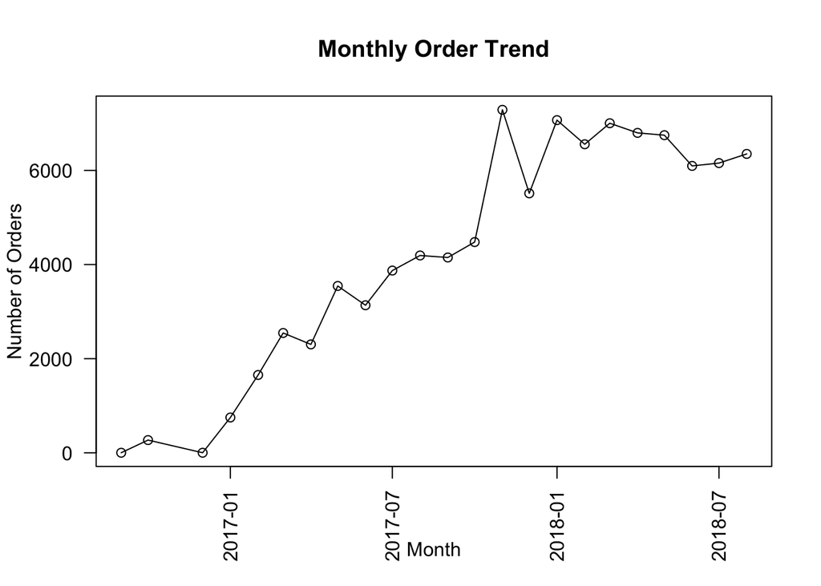

```r
# Grouping orders by month and counting them
# Siparişleri ay bazında gruplayıp sayıyoruz
monthly_orders <- aggregate(order_id ~ format(order_purchase_timestamp, "%Y-%m"), data=orders, FUN=length)

# Rename columns for clarity
# Kolonları daha anlaşılır hale getiriyoruz
colnames(monthly_orders) <- c("Month", "Number_of_Orders")

# Plotting the monthly order trend
# Aylık sipariş trendini çiziyoruz
plot(as.Date(paste0(monthly_orders$Month, "-01")), monthly_orders$Number_of_Orders, type='o', main='Monthly Order Trend', xlab='Month', ylab='Number of Orders', las=2)
```

```r
# Displaying the monthly orders in a table format
# Aylık siparişleri tablo formatında görüntülüyoruz
print(monthly_orders)
```

```
##      Month Number_of_Orders
## 1  2016-09                1
## 2  2016-10              270
## 3  2016-12                1
## 4  2017-01              750
## 5  2017-02             1653
## 6  2017-03             2546
## 7  2017-04             2303
## 8  2017-05             3545
## 9  2017-06             3135
## 10 2017-07             3872
## 11 2017-08             4193
## 12 2017-09             4150
## 13 2017-10             4478
## 14 2017-11             7288
## 15 2017-12             5513
## 16 2018-01             7069
## 17 2018-02             6556
## 18 2018-03             7003
## 19 2018-04             6798
## 20 2018-05             6749
## 21 2018-06             6096
## 22 2018-07             6156
## 23 2018-08             6351
```

#### Alternatif Olarak Daha Anlaşılır Bir Tablo - Alternatively Displaying as a Data Frame

Eğer daha güzel bir tablo görünümü isterseniz, kable fonksiyonunu kullanarak tabloyu formatlayabilirsiniz. Bunun için **knitr** paketini kullanabilirsiniz: If you want a more beautiful table view, you can format the table using the kable function. For this, you can use the **knitr** package:

```r
# Load the knitr package for better table formatting
# Daha iyi tablo formatlaması için knitr paketini yüklüyoruz
library(knitr)

# Displaying the monthly orders using kable for better formatting
# Kable kullanarak aylık siparişleri daha iyi formatlayarak görüntülüyoruz
kable(monthly_orders, caption = "Monthly Orders Summary", col.names = c("Month", "Number of Orders"))
```

Monthly Orders Summary

| Month | Number of Orders |
| --- | --- |
| 2016-09 | 1 |
| 2016-10 | 270 |
| 2016-12 | 1 |
| 2017-01 | 750 |
| 2017-02 | 1653 |
| 2017-03 | 2546 |
| 2017-04 | 2303 |
| 2017-05 | 3545 |
| 2017-06 | 3135 |
| 2017-07 | 3872 |
| 2017-08 | 4193 |
| 2017-09 | 4150 |
| 2017-10 | 4478 |
| 2017-11 | 7288 |
| 2017-12 | 5513 |
| 2018-01 | 7069 |
| 2018-02 | 6556 |
| 2018-03 | 7003 |
| 2018-04 | 6798 |
| 2018-05 | 6749 |
| 2018-06 | 6096 |
| 2018-07 | 6156 |
| 2018-08 | 6351 |

#### Zaman Serisi Analizinin Genişletilmesi - Expanding Time Series Analysis

1. Hafta İçi ve Hafta Sonu Alışveriş Tutarları - Comparing Weekday and Weekend Purchases
- Sipariş Tarihini Kullanma: Sipariş tarihinden gün bilgisini alarak siparişlerin hafta içi (Pazartesi-Cuma) veya hafta sonu (Cumartesi-Pazar) olup olmadığını belirleyebiliriz. Using Order Date: By taking the day information from the order date, we can determine whether the orders are weekday (Monday-Friday) or weekend (Saturday-Sunday).
- Sipariş Tutarlarının Karşılaştırılması: Haftanın günlerine göre sipariş tutarlarını karşılaştırabiliriz. Comparing Order Amounts: We can compare order amounts according to the days of the week.

#### A) Gün Bilgisi Ekleme - Adding Day Information

Öncelikle, sipariş tarihlerini kullanarak hangi günlerde sipariş verildiğini belirleyelim: First, let’s determine which days the orders are placed using the order dates:

```r
# Add a new column for day of the week
# Haftanın gününü belirlemek için yeni bir sütun ekliyoruz
orders$day_of_week <- weekdays(orders$order_purchase_timestamp)

# Check the first few rows to ensure the new column is added
# Yeni sütunun eklendiğinden emin olmak için ilk birkaç satırı kontrol edelim
head(orders)
```

```
##                           order_id                      customer_id order_status
## 1 e481f51cbdc54678b7cc49136f2d6af7 9ef432eb6251297304e76186b10a928d    delivered
## 2 53cdb2fc8bc7dce0b6741e2150273451 b0830fb4747a6c6d20dea0b8c802d7ef    delivered
## 3 47770eb9100c2d0c44946d9cf07ec65d 41ce2a54c0b03bf3443c3d931a367089    delivered
## 4 949d5b44dbf5de918fe9c16f97b45f8a f88197465ea7920adcdbec7375364d82    delivered
## 5 ad21c59c0840e6cb83a9ceb5573f8159 8ab97904e6daea8866dbdbc4fb7aad2c    delivered
## 6 a4591c265e18cb1dcee52889e2d8acc3 503740e9ca751ccdda7ba28e9ab8f608    delivered
##   order_purchase_timestamp   order_approved_at order_delivered_carrier_date
## 1               2017-10-02 2017-10-02 11:07:15          2017-10-04 19:55:00
## 2               2018-07-24 2018-07-26 03:24:27          2018-07-26 14:31:00
## 3               2018-08-08 2018-08-08 08:55:23          2018-08-08 13:50:00
## 4               2017-11-18 2017-11-18 19:45:59          2017-11-22 13:39:59
## 5               2018-02-13 2018-02-13 22:20:29          2018-02-14 19:46:34
## 6               2017-07-09 2017-07-09 22:10:13          2017-07-11 14:58:04
##   order_delivered_customer_date order_estimated_delivery_date day_of_week
## 1                    2017-10-10                    2017-10-18      Monday
## 2                    2018-08-07                    2018-08-13     Tuesday
## 3                    2018-08-17                    2018-09-04   Wednesday
## 4                    2017-12-02                    2017-12-15    Saturday
## 5                    2018-02-16                    2018-02-26     Tuesday
## 6                    2017-07-26                    2017-08-01      Sunday
```

#### B) Hafta İçi ve Hafta Sonu Karşılaştırması - Comparing Weekdays and Weekends

```r
# Add a new column for day of the week
# Haftanın gününü belirlemek için yeni bir sütun ekliyoruz
orders$day_of_week <- weekdays(orders$order_purchase_timestamp)

# Check the first few rows to ensure the new column is added
# Yeni sütunun eklendiğinden emin olmak için ilk birkaç satırı kontrol edelim
head(orders)
```

```
##                           order_id                      customer_id order_status
## 1 e481f51cbdc54678b7cc49136f2d6af7 9ef432eb6251297304e76186b10a928d    delivered
## 2 53cdb2fc8bc7dce0b6741e2150273451 b0830fb4747a6c6d20dea0b8c802d7ef    delivered
## 3 47770eb9100c2d0c44946d9cf07ec65d 41ce2a54c0b03bf3443c3d931a367089    delivered
## 4 949d5b44dbf5de918fe9c16f97b45f8a f88197465ea7920adcdbec7375364d82    delivered
## 5 ad21c59c0840e6cb83a9ceb5573f8159 8ab97904e6daea8866dbdbc4fb7aad2c    delivered
## 6 a4591c265e18cb1dcee52889e2d8acc3 503740e9ca751ccdda7ba28e9ab8f608    delivered
##   order_purchase_timestamp   order_approved_at order_delivered_carrier_date
## 1               2017-10-02 2017-10-02 11:07:15          2017-10-04 19:55:00
## 2               2018-07-24 2018-07-26 03:24:27          2018-07-26 14:31:00
## 3               2018-08-08 2018-08-08 08:55:23          2018-08-08 13:50:00
## 4               2017-11-18 2017-11-18 19:45:59          2017-11-22 13:39:59
## 5               2018-02-13 2018-02-13 22:20:29          2018-02-14 19:46:34
## 6               2017-07-09 2017-07-09 22:10:13          2017-07-11 14:58:04
##   order_delivered_customer_date order_estimated_delivery_date day_of_week
## 1                    2017-10-10                    2017-10-18      Monday
## 2                    2018-08-07                    2018-08-13     Tuesday
## 3                    2018-08-17                    2018-09-04   Wednesday
## 4                    2017-12-02                    2017-12-15    Saturday
## 5                    2018-02-16                    2018-02-26     Tuesday
## 6                    2017-07-26                    2017-08-01      Sunday
```

```r
# Create a new column for weekend/weekday
# Hafta sonu/hafta içi için yeni bir sütun oluşturuyoruz
orders$week_part <- ifelse(orders$day_of_week %in% c("Saturday", "Sunday"), "Weekend", "Weekday")

# Check the first few rows to ensure the new column is added
# Yeni sütunun eklendiğinden emin olmak için ilk birkaç satırı kontrol edelim
head(orders)
```

```
##                           order_id                      customer_id order_status
## 1 e481f51cbdc54678b7cc49136f2d6af7 9ef432eb6251297304e76186b10a928d    delivered
## 2 53cdb2fc8bc7dce0b6741e2150273451 b0830fb4747a6c6d20dea0b8c802d7ef    delivered
## 3 47770eb9100c2d0c44946d9cf07ec65d 41ce2a54c0b03bf3443c3d931a367089    delivered
## 4 949d5b44dbf5de918fe9c16f97b45f8a f88197465ea7920adcdbec7375364d82    delivered
## 5 ad21c59c0840e6cb83a9ceb5573f8159 8ab97904e6daea8866dbdbc4fb7aad2c    delivered
## 6 a4591c265e18cb1dcee52889e2d8acc3 503740e9ca751ccdda7ba28e9ab8f608    delivered
##   order_purchase_timestamp   order_approved_at order_delivered_carrier_date
## 1               2017-10-02 2017-10-02 11:07:15          2017-10-04 19:55:00
## 2               2018-07-24 2018-07-26 03:24:27          2018-07-26 14:31:00
## 3               2018-08-08 2018-08-08 08:55:23          2018-08-08 13:50:00
## 4               2017-11-18 2017-11-18 19:45:59          2017-11-22 13:39:59
## 5               2018-02-13 2018-02-13 22:20:29          2018-02-14 19:46:34
## 6               2017-07-09 2017-07-09 22:10:13          2017-07-11 14:58:04
##   order_delivered_customer_date order_estimated_delivery_date day_of_week week_part
## 1                    2017-10-10                    2017-10-18      Monday   Weekday
## 2                    2018-08-07                    2018-08-13     Tuesday   Weekday
## 3                    2018-08-17                    2018-09-04   Wednesday   Weekday
## 4                    2017-12-02                    2017-12-15    Saturday   Weekend
## 5                    2018-02-16                    2018-02-26     Tuesday   Weekday
## 6                    2017-07-26                    2017-08-01      Sunday   Weekend
```

```r
# Join the 'orders' and 'order_payments' datasets to combine information
# Bilgileri birleştirmek için 'orders' ve 'order_payments' veri setlerini birleştiriyoruz
combined_data <- merge(orders, order_payments, by = "order_id")

# Grouping orders by week part and summing payment values
# Hafta içi ve hafta sonu sipariş tutarlarını toplamak için grupluyoruz
weekly_orders <- aggregate(payment_value ~ week_part, data=combined_data, FUN=sum)

# Displaying the result
# Sonucu görüntülüyoruz
print(weekly_orders)
```

```
##   week_part payment_value
## 1   Weekday      11907805
## 2   Weekend       3514027
```

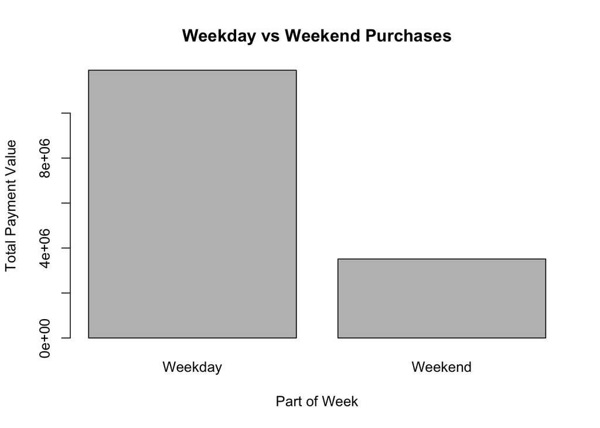

```r
# Barplot for weekday vs weekend purchases
# Hafta içi ve hafta sonu alışveriş tutarlarını gösteren çubuk grafiği
barplot(weekly_orders$payment_value, names.arg=weekly_orders$week_part, main='Weekday vs Weekend Purchases', xlab='Part of Week', ylab='Total Payment Value')
```

```r
# Load ggplot2 package
# ggplot2 paketini yüklüyoruz
library(ggplot2)
```

#### Görsel İyileştirme - Visual enhancement

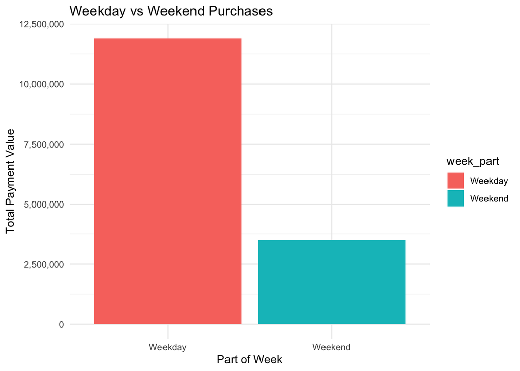

```r
# Create a bar plot for weekday vs weekend purchases using ggplot2
# Hafta içi ve hafta sonu alışveriş tutarlarını gösteren çubuk grafiği (ggplot2 kullanarak)
ggplot(weekly_orders, aes(x=week_part, y=payment_value, fill=week_part)) +
  geom_bar(stat="identity") +
  labs(title='Weekday vs Weekend Purchases', x='Part of Week', y='Total Payment Value') +
  scale_y_continuous(labels = scales::comma) +  # Y eksenindeki değerleri daha anlaşılır hale getiriyoruz
  theme_minimal()
```

### Müşteri Segmentasyonu - Customer Segmentation

Müşteri segmentasyonu yapmak için aşağıdaki adımları izleyebiliriz:

#### A) Müşteri Verilerinin İncelenmesi - Exploring Customer Data

Öncelikle, müşteri veri setini (orders_df, customers_df) inceleyelim ve hangi özellikleri kullanabileceğimizi görelim.

```r
# Müşteri veri setinin ilk birkaç satırını görüntüleyelim
# Viewing the first few rows of the customer dataset
head(customers)
```

```
##                        customer_id               customer_unique_id customer_zip_code_prefix
## 1 06b8999e2fba1a1fbc88172c00ba8bc7 861eff4711a542e4b93843c6dd7febb0                    14409
## 2 18955e83d337fd6b2def6b18a428ac77 290c77bc529b7ac935b93aa66c333dc3                     9790
## 3 4e7b3e00288586ebd08712fdd0374a03 060e732b5b29e8181a18229c7b0b2b5e                     1151
## 4 b2b6027bc5c5109e529d4dc6358b12c3 259dac757896d24d7702b9acbbff3f3c                     8775
## 5 4f2d8ab171c80ec8364f7c12e35b23ad 345ecd01c38d18a9036ed96c73b8d066                    13056
## 6 879864dab9bc3047522c92c82e1212b8 4c93744516667ad3b8f1fb645a3116a4                    89254
##           customer_city customer_state
## 1                franca             SP
## 2 sao bernardo do campo             SP
## 3             sao paulo             SP
## 4       mogi das cruzes             SP
## 5              campinas             SP
## 6        jaragua do sul             SC
```

#### B) Demografik Özellikler - Demographic Features

Müşteri verilerini demografik özelliklere göre gruplandırabiliriz. Örneğin, müşteri şehirleri veya eyaletlerine göre segmentler oluşturabiliriz.

- Müşteri Şehirlerine Göre Segmentasyon - Segmenting by Customer Cities

```r
# Grouping customers by city and counting the number of customers
# Müşterileri şehir bazında gruplandırıp müşteri sayısını hesaplıyoruz
city_segments <- table(customers$customer_city)

# Creating a data frame for better visualization
# Daha iyi görselleştirme için bir veri çerçevesi oluşturuyoruz
city_segments_df <- as.data.frame(city_segments)
colnames(city_segments_df) <- c("City", "Number_of_Customers")

# Displaying the top cities by number of customers
# Müşteri sayısına göre en çok müşteriye sahip şehirleri görüntülüyoruz
top_cities <- head(city_segments_df[order(-city_segments_df$Number_of_Customers), ], 10)
print(top_cities)
```

```
##                       City Number_of_Customers
## 3598             sao paulo               15540
## 3156        rio de janeiro                6882
## 454         belo horizonte                2773
## 559               brasilia                2131
## 1144              curitiba                1521
## 708               campinas                1444
## 2965          porto alegre                1379
## 3248              salvador                1245
## 1530             guarulhos                1189
## 3429 sao bernardo do campo                 938
```

```r
# Grouping customers by state and counting the number of customers
# Müşterileri eyalet bazında gruplandırıp müşteri sayısını hesaplıyoruz
state_segments <- table(customers$customer_state)

# Creating a data frame for better visualization
# Daha iyi görselleştirme için bir veri çerçevesi oluşturuyoruz
state_segments_df <- as.data.frame(state_segments)
colnames(state_segments_df) <- c("State", "Number_of_Customers")

# Displaying the top states by number of customers
# Müşteri sayısına göre en çok müşteriye sahip eyaletleri görüntülüyoruz
top_states <- head(state_segments_df[order(-state_segments_df$Number_of_Customers), ], 10)
print(top_states)
```

```
##    State Number_of_Customers
## 26    SP               41746
## 19    RJ               12852
## 11    MG               11635
## 23    RS                5466
## 18    PR                5045
## 24    SC                3637
## 5     BA                3380
## 7     DF                2140
## 8     ES                2033
## 9     GO                2020
```

```r
# Grouping customers by payment type and counting the number of customers
# Müşterileri ödeme türlerine göre gruplandırıp müşteri sayısını hesaplıyoruz
payment_segments <- table(order_payments$payment_type)

# Creating a data frame for better visualization
# Daha iyi görselleştirme için bir veri çerçevesi oluşturuyoruz
payment_segments_df <- as.data.frame(payment_segments)
colnames(payment_segments_df) <- c("Payment_Type", "Number_of_Customers")

# Displaying the payment method distribution
# Ödeme yöntemi dağılımını görüntülüyoruz
print(payment_segments_df)
```

```
##   Payment_Type Number_of_Customers
## 1       boleto               19784
## 2  credit_card               76795
## 3   debit_card                1529
## 4  not_defined                   3
## 5      voucher                5775
```

#### A) Müşteri Verileri - Customer Data

**- Müşteri Şehirleri ve Eyaletleri:Customer Cities and States:**

- customer_city ve customer_state sütunları, müşterilerin yaşadığı şehir ve eyalet bilgilerini içeriyor. The customer_city and customer_state columns contain information about the cities and states where the customers reside.
- Örneğin, São Paulo (SP) eyaletindeki en fazla müşteri sayısına sahip şehir, toplamda 15,540 müşteri ile São Paulo. For example, the city with the highest number of customers in the state of São Paulo (SP) is São Paulo, with a total of 15,540 customers.

#### B) Müşteri Segmentasyonu Sonuçları - Customer Segmentation Results

1. Şehirlere Göre Müşteri Sayısı - Number of Customers by City:

**Top Müşteri Şehirleri:Top Customer Cities:** - São Paulo, Rio de Janeiro, Belo Horizonte gibi şehirler, büyük müşteri kitlelerine sahip. Cities like São Paulo, Rio de Janeiro, and Belo Horizonte have large customer bases.

- Bu şehirlerdeki yoğun müşteri sayısı, yerel pazarlama stratejilerinin geliştirilmesine yardımcı olabilir. The significant customer numbers in these cities can aid in developing local marketing strategies.
2. Eyaletlere Göre Müşteri Sayısı - Number of Customers by State:

**Müşteri Sayısının Dağılımı:Distribution of Customer Numbers:**

- São Paulo (SP) eyaletinde 41,746 müşteri bulunuyor. The state of São Paulo (SP) has 41,746 customers.
- Diğer eyaletler, örneğin Rio de Janeiro (RJ) 12,852 müşteri ile geliyor. Other states, such as Rio de Janeiro (RJ), have 12,852 customers.

Bu bilgiler, hangi eyaletlerde daha fazla pazarlama yapılması gerektiğini gösterir. This information indicates where more marketing efforts may be needed.

#### C) Ödeme Yöntemlerine Göre Müşteri Dağılımı - Customer Distribution by Payment Method

**Ödeme Yöntemleri:Payment Methods:**

- Boleto: 19,784 müşteri Boleto: 19,784 customers
- Kredi Kartı: 76,795 müşteri Credit Card: 76,795 customers
- Debit Kart: 1,529 müşteri Debit Card: 1,529 customers
- Tanımsız: 3 müşteri Not Defined: 3 customers
- Vouchere: 5,775 müşteri Voucher: 5,775 customers
- Kredi kartı, en fazla müşteri sayısına sahip ödeme yöntemi olarak öne çıkıyor. The credit card stands out as the payment method with the highest number of customers.
- Bu, kredi kartı ödemelerini teşvik eden stratejilerin ne kadar etkili olabileceğini gösteriyor. This indicates how effective strategies encouraging credit card payments could be.

#### Öneriler - Recommendations

**Pazarlama Stratejileri:Marketing Strategies:**

- En çok müşteri sayısına sahip şehirler ve eyaletler üzerinde hedeflenmiş kampanyalar düzenlemek. Implement targeted campaigns in cities and states with the highest customer numbers.

**Ödeme Yöntemlerinin Teşviki:Encouraging Payment Methods:**

- Kredi kartı kullanımını artırmak için özel indirimler veya taksit seçenekleri sunmak. Offer special discounts or installment options to increase credit card usage.

**Demografik Analiz:Demographic Analysis:**

- Müşterilerin demografik özelliklerine (yaş, cinsiyet) göre daha fazla segment oluşturmak, daha hedefli pazarlama stratejileri geliştirmek için faydalı olacaktır. Creating more segments based on customer demographics (age, gender) will be beneficial for developing more targeted marketing strategies.

### Daha derin analizlere girebiliriz - We can do much deeper analysis

#### A) Ürün Kategorilerine Göre Satışların İncelenmesi - Analyzing Sales by Product Category

1. Veri Setini İnceleyelim - Let’s Explore the Dataset

```r
# Display the first few rows of the product dataset
# Ürün veri setinin ilk birkaç satırını görüntülüyoruz
head(products)
```

```
##                         product_id product_category_name product_name_lenght
## 1 1e9e8ef04dbcff4541ed26657ea517e5            perfumaria                  40
## 2 3aa071139cb16b67ca9e5dea641aaa2f                 artes                  44
## 3 96bd76ec8810374ed1b65e291975717f         esporte_lazer                  46
## 4 cef67bcfe19066a932b7673e239eb23d                 bebes                  27
## 5 9dc1a7de274444849c219cff195d0b71 utilidades_domesticas                  37
## 6 41d3672d4792049fa1779bb35283ed13 instrumentos_musicais                  60
##   product_description_lenght product_photos_qty product_weight_g product_length_cm product_height_cm
## 1                        287                  1              225                16                10
## 2                        276                  1             1000                30                18
## 3                        250                  1              154                18                 9
## 4                        261                  1              371                26                 4
## 5                        402                  4              625                20                17
## 6                        745                  1              200                38                 5
##   product_width_cm
## 1               14
## 2               20
## 3               15
## 4               26
## 5               13
## 6               11
```

2. Ürün Kategorileri ve Satış Değerlerini Gruplama - Grouping Product Categories and Sales Values

```r
# Merge the order_items and order_payments datasets by 'order_id'
# 'order_id' üzerinden order_items ve order_payments veri setlerini birleştiriyoruz
merged_items_payments <- merge(order_items, order_payments, by="order_id")

# Merge the result with the products dataset by 'product_id'
# Sonucu products veri seti ile 'product_id' üzerinden birleştiriyoruz
merged_data <- merge(merged_items_payments, products, by="product_id")

# Grouping by product category and summing up the payment values
# Ürün kategorilerine göre gruplandırıp toplam ödeme değerlerini hesaplıyoruz
category_sales <- aggregate(payment_value ~ product_category_name, data=merged_data, FUN=sum)

# Sorting categories by total sales value
# Kategorileri toplam satış değerine göre sıralıyoruz
category_sales <- category_sales[order(-category_sales$payment_value), ]

# Displaying the top categories by sales
# Satışlara göre en çok satan kategorileri görüntülüyoruz
head(category_sales, 10)
```

```
##     product_category_name payment_value
## 14        cama_mesa_banho     1712553.7
## 12           beleza_saude     1657373.1
## 45 informatica_acessorios     1585330.4
## 55       moveis_decoracao     1430176.4
## 67     relogios_presentes     1429216.7
## 33          esporte_lazer     1392127.6
## 73  utilidades_domesticas     1094758.1
## 9              automotivo      852294.3
## 41     ferramentas_jardim      838280.8
## 27             cool_stuff      779698.0
```

#### Çıktı Sonuçlarının Yorumu - Interpretation of the Results

**En Çok Satış Yapan Kategoriler:Most Preferred Categories**

- cama_mesa_banho (Yatak, masa ve banyo ürünleri) toplamda 1,712,553.7 BRL ödeme değeri ile en çok satış yapan kategori.
- cama_mesa_banho (Bedding, table, and bath products) is the top-selling category with a total payment value of 1,712,553.7 BRL.
- beleza_saude (Güzellik ve sağlık) kategorisi 1,657,373.1 BRL ile ikinci sırada. beleza_saude (Beauty and health) is the second top-selling category with a total of 1,657,373.1 BRL.
- informatica_acessorios (Bilgisayar aksesuarları) 1,585,330.4 BRL ile üçüncü sırada. informatica_acessorios (Computer accessories) ranks third with 1,585,330.4 BRL.

**Popüler Kategoriler:Popular Categories**

- Bu liste, hangi ürün kategorilerinin müşteriler tarafından en çok tercih edildiğini gösterir. This list shows which product categories are most preferred by customers.
- En çok satış yapan kategoriler, yatak/masa/banyo, güzellik/sağlık ve bilgisayar aksesuarları gibi çeşitli ürün gruplarına yayıldı. The top-selling categories span a variety of product groups such as bedding/table/bath, beauty/health, and computer accessories.

#### Sonraki Adımlar - Next Steps

**Görselleştirme - Visualization:**

- Bu sonuçları daha iyi anlamak için bir çubuk grafiği oluşturabiliriz. Böylece en çok satış yapan ürün kategorilerini görsel olarak inceleyebiliriz. To better understand these results, we can create a bar plot to visualize the top-selling product categories.

**Daha Fazla Segmentasyon - Further Segmentation:**

- Ürün kategorilerini şehir veya eyalet gibi farklı segmentlerle birleştirerek hangi kategorilerin hangi bölgelerde daha popüler olduğunu inceleyebiliriz. We can combine product categories with different segments such as city or state to analyze which categories are more popular in certain regions.

#### A) Görselleştirme - Visualization

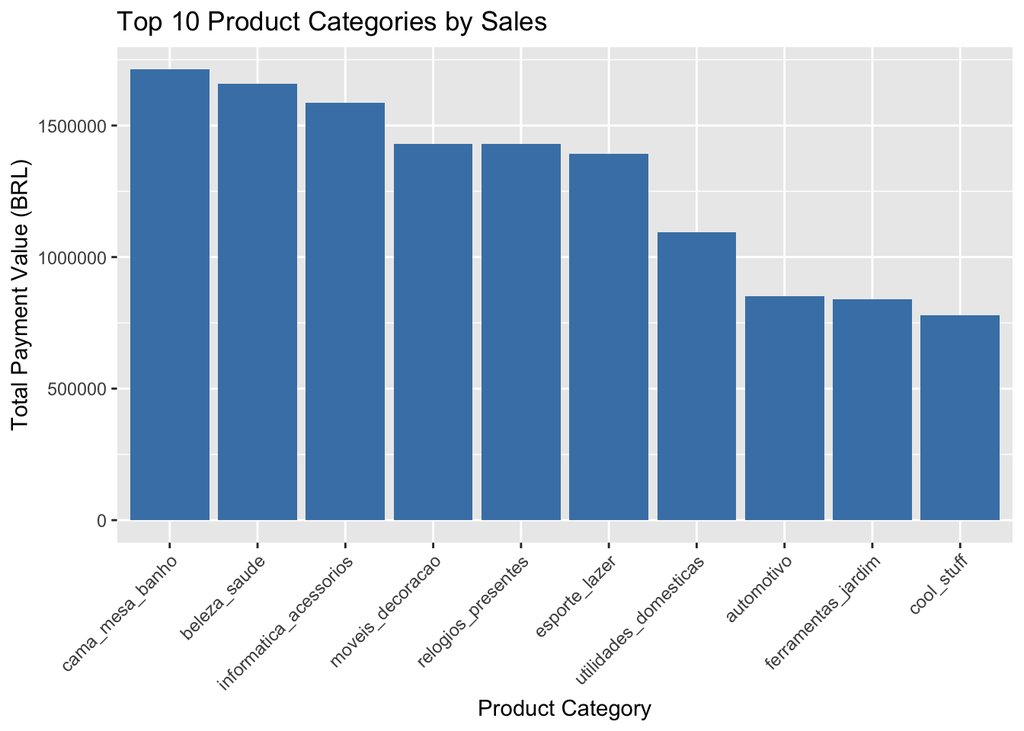

```r
# Bar plot for the top product categories by sales
# En çok satış yapan ürün kategorilerini gösteren çubuk grafiği
library(ggplot2)

# En çok satış yapan ilk 10 kategoriye göre çubuk grafiği oluşturuyoruz
# Creating a bar plot for the top 10 selling categories
ggplot(category_sales[1:10, ], aes(x=reorder(product_category_name, -payment_value), y=payment_value)) +

  # Çubuk grafiği için 'geom_bar' fonksiyonunu kullanıyoruz
  # Using 'geom_bar' function to create the bar plot
  geom_bar(stat="identity", fill="steelblue") +

  # Başlık ve etiketler ekliyoruz
  # Adding title and labels
  labs(title="Top 10 Product Categories by Sales",
       x="Product Category",
       y="Total Payment Value (BRL)") +

  # X eksenindeki etiketleri 45 derece eğiyoruz
  # Rotating the labels on the x-axis by 45 degrees for readability
  theme(axis.text.x = element_text(angle=45, hjust=1))
```

#### A) Ürün Kategorileri ve Eyaletlere Göre Satışların Analizi - Analyzing Sales by Product Categories and States

1. Veri Setlerini Birleştirme - Merging the Datasets

```r
# Check the column names of each dataset
# Her veri setinin sütun adlarını kontrol edelim
colnames(order_items)
```

```
## [1] "order_id"            "order_item_id"       "product_id"          "seller_id"
## [5] "shipping_limit_date" "price"               "freight_value"
```

```r
colnames(order_payments)
```

```
## [1] "order_id"             "payment_sequential"   "payment_type"         "payment_installments"
## [5] "payment_value"
```

```r
colnames(products)
```

```
## [1] "product_id"                 "product_category_name"      "product_name_lenght"
## [4] "product_description_lenght" "product_photos_qty"         "product_weight_g"
## [7] "product_length_cm"          "product_height_cm"          "product_width_cm"
```

```r
colnames(customers)
```

```
## [1] "customer_id"              "customer_unique_id"       "customer_zip_code_prefix"
## [4] "customer_city"            "customer_state"
```

```r
# Check for duplicates in customer_id in customers dataset
# customers veri setinde customer_id sütununda tekrar eden değerleri kontrol edelim
sum(duplicated(customers$customer_id))
```

```
## [1] 0
```

```r
# Check for duplicates in order_id in order_items dataset
# order_items veri setinde order_id sütununda tekrar eden değerleri kontrol edelim
sum(duplicated(order_items$order_id))
```

```
## [1] 13984
```

```r
# Check for duplicates in order_id in order_payments dataset
# order_payments veri setinde order_id sütununda tekrar eden değerleri kontrol edelim
sum(duplicated(order_payments$order_id))
```

```
## [1] 4446
```

**Çözüm - Solution:**

```r
# Check the columns of merged_items_payments dataset
# merged_items_payments veri setinin sütunlarını kontrol edelim
colnames(merged_items_payments)
```

```
##  [1] "order_id"             "order_item_id"        "product_id"           "seller_id"
##  [5] "shipping_limit_date"  "price"                "freight_value"        "payment_sequential"
##  [9] "payment_type"         "payment_installments" "payment_value"
```

```r
# Check the columns of merged_data
# merged_data veri setinin sütunlarını kontrol edelim
colnames(merged_data)
```

```
##  [1] "product_id"                 "order_id"                   "order_item_id"
##  [4] "seller_id"                  "shipping_limit_date"        "price"
##  [7] "freight_value"              "payment_sequential"         "payment_type"
## [10] "payment_installments"       "payment_value"              "product_category_name"
## [13] "product_name_lenght"        "product_description_lenght" "product_photos_qty"
## [16] "product_weight_g"           "product_length_cm"          "product_height_cm"
## [19] "product_width_cm"
```

```r
# Check the columns of customers dataset
# customers veri setinin sütunlarını kontrol edelim
colnames(customers)
```

```
## [1] "customer_id"              "customer_unique_id"       "customer_zip_code_prefix"
## [4] "customer_city"            "customer_state"
```

```r
# Check for duplicates in customer_id in customers dataset
# customers veri setinde customer_id sütununda tekrar eden değerleri kontrol edelim
sum(duplicated(customers$customer_id))
```

```
## [1] 0
```

```r
# Check the column names of merged_data to ensure customer_id exists
# merged_data veri setinin sütun adlarını kontrol ediyoruz
colnames(merged_data)
```

```
##  [1] "product_id"                 "order_id"                   "order_item_id"
##  [4] "seller_id"                  "shipping_limit_date"        "price"
##  [7] "freight_value"              "payment_sequential"         "payment_type"
## [10] "payment_installments"       "payment_value"              "product_category_name"
## [13] "product_name_lenght"        "product_description_lenght" "product_photos_qty"
## [16] "product_weight_g"           "product_length_cm"          "product_height_cm"
## [19] "product_width_cm"
```

```r
# Check the columns of order_items to verify if customer_id is present
# order_items veri setinin sütunlarını kontrol ediyoruz
colnames(order_items)
```

```
## [1] "order_id"            "order_item_id"       "product_id"          "seller_id"
## [5] "shipping_limit_date" "price"               "freight_value"
```

```r
# Check the columns of order_payments to verify if customer_id is present
# order_payments veri setinin sütunlarını kontrol ediyoruz
colnames(order_payments)
```

```
## [1] "order_id"             "payment_sequential"   "payment_type"         "payment_installments"
## [5] "payment_value"
```

```r
# Check the columns of orders dataset
# orders veri setinin sütunlarını kontrol ediyoruz
colnames(orders)
```

```
##  [1] "order_id"                      "customer_id"                   "order_status"
##  [4] "order_purchase_timestamp"      "order_approved_at"             "order_delivered_carrier_date"
##  [7] "order_delivered_customer_date" "order_estimated_delivery_date" "day_of_week"
## [10] "week_part"
```

```r
# Merge order_items with orders to get customer_id
# order_items ve orders veri setlerini birleştirerek customer_id değerini alıyoruz
order_items_with_customers <- merge(order_items, orders, by="order_id")

# Merge order_items_with_customers with order_payments using 'order_id'
# order_items_with_customers veri setini order_payments ile 'order_id' kullanarak birleştiriyoruz
merged_items_payments <- merge(order_items_with_customers, order_payments, by="order_id")

# Merge the result with the products dataset using 'product_id'
# Sonucu products veri seti ile 'product_id' kullanarak birleştiriyoruz
final_merged_data <- merge(merged_items_payments, products, by="product_id")

# Check the first few rows of the final merged dataset
# Birleştirilen son veri setinin ilk birkaç satırını kontrol ediyoruz
head(final_merged_data)
```

```
##                         product_id                         order_id order_item_id
## 1 00066f42aeeb9f3007548bb9d3f33c38 f30149f4a8882a08895b6a242aa0d612             1
## 2 00088930e925c41fd95ebfe695fd2655 f5eda0ded77c1293b04c953138c8331d             1
## 3 0009406fd7479715e4bef61dd91f2462 0bf736fd0fd5169d60de3699fcbcf986             1
## 4 000b8f95fcb9e0096488278317764d19 3aba44d8e554ab4bb8c09f6f78032ca8             1
## 5 000b8f95fcb9e0096488278317764d19 6f0dfb5b5398b271cc6bbd9ee263530e             1
## 6 000d9be29b5207b54e86aa1b1ac54872 a6c1ae4d48280b5b3c43231ac6afd701             1
##                          seller_id shipping_limit_date  price freight_value
## 1 5670f4db5b62c43d542e1b2d56b0cf7c 2018-05-24 18:58:59 101.65         18.59
## 2 7142540dd4c91e2237acb7e911c4eba2 2017-12-18 19:32:19 129.90         13.93
## 3 4a3ca9315b744ce9f8e9374361493884 2017-12-29 16:12:36 229.00         13.10
## 4 40ec8ab6cdafbcc4f544da38c67da39a 2018-08-16 13:35:21  58.90         19.60
## 5 40ec8ab6cdafbcc4f544da38c67da39a 2018-08-07 22:15:19  58.90         19.60
## 6 8ae520247981aa06bc94abddf5f46d34 2018-04-09 10:09:40 199.00         19.27
##                        customer_id order_status order_purchase_timestamp   order_approved_at
```

[output cut: 34 more lines]

```r
# Check the columns of final_merged_data
# final_merged_data veri setinin sütunlarını kontrol edelim
colnames(final_merged_data)
```

```
##  [1] "product_id"                    "order_id"                      "order_item_id"
##  [4] "seller_id"                     "shipping_limit_date"           "price"
##  [7] "freight_value"                 "customer_id"                   "order_status"
## [10] "order_purchase_timestamp"      "order_approved_at"             "order_delivered_carrier_date"
## [13] "order_delivered_customer_date" "order_estimated_delivery_date" "day_of_week"
## [16] "week_part"                     "payment_sequential"            "payment_type"
## [19] "payment_installments"          "payment_value"                 "product_category_name"
## [22] "product_name_lenght"           "product_description_lenght"    "product_photos_qty"
## [25] "product_weight_g"              "product_length_cm"             "product_height_cm"
## [28] "product_width_cm"
```

```r
# Merge order_items with orders to get customer_id and customer_state
# order_items ile orders veri setini birleştirerek customer_id ve customer_state alıyoruz
order_items_with_customers <- merge(order_items, orders, by="order_id")

# Merge order_items_with_customers with order_payments using 'order_id'
# order_items_with_customers veri setini order_payments ile 'order_id' kullanarak birleştiriyoruz
merged_items_payments <- merge(order_items_with_customers, order_payments, by="order_id")

# Merge the result with the products dataset using 'product_id'
# Sonucu products veri seti ile 'product_id' kullanarak birleştiriyoruz
final_merged_data <- merge(merged_items_payments, products, by="product_id")

# Check the columns of final_merged_data to ensure customer_state exists
# final_merged_data veri setinin sütun adlarını kontrol ediyoruz
colnames(final_merged_data)
```

```
##  [1] "product_id"                    "order_id"                      "order_item_id"
##  [4] "seller_id"                     "shipping_limit_date"           "price"
##  [7] "freight_value"                 "customer_id"                   "order_status"
## [10] "order_purchase_timestamp"      "order_approved_at"             "order_delivered_carrier_date"
## [13] "order_delivered_customer_date" "order_estimated_delivery_date" "day_of_week"
## [16] "week_part"                     "payment_sequential"            "payment_type"
## [19] "payment_installments"          "payment_value"                 "product_category_name"
## [22] "product_name_lenght"           "product_description_lenght"    "product_photos_qty"
## [25] "product_weight_g"              "product_length_cm"             "product_height_cm"
## [28] "product_width_cm"
```

```r
# If customer_state exists, proceed to analyze sales by state and product category
# customer_state varsa, eyalet ve ürün kategorisine göre satış analizi yapmaya devam ediyoruz
```

```r
# Merge orders with customers to obtain customer_state
# orders veri setini customers ile birleştirerek customer_state değerini alıyoruz
orders_with_customers <- merge(orders, customers, by="customer_id")

# Merge order_items with the merged orders_customers dataset using 'order_id'
# order_items veri setini birleştirilen orders_with_customers veri seti ile 'order_id' kullanarak birleştiriyoruz
order_items_with_customers <- merge(order_items, orders_with_customers, by="order_id")

# Merge with order_payments using 'order_id'
# order_items_with_customers veri setini order_payments ile 'order_id' kullanarak birleştiriyoruz
merged_items_payments <- merge(order_items_with_customers, order_payments, by="order_id")

# Merge the result with the products dataset using 'product_id'
# Sonucu products veri seti ile 'product_id' kullanarak birleştiriyoruz
final_merged_data <- merge(merged_items_payments, products, by="product_id")

# Check the columns of final_merged_data to ensure customer_state exists
# final_merged_data veri setinin sütun adlarını kontrol ediyoruz
colnames(final_merged_data)
```

```
##  [1] "product_id"                    "order_id"                      "order_item_id"
##  [4] "seller_id"                     "shipping_limit_date"           "price"
##  [7] "freight_value"                 "customer_id"                   "order_status"
## [10] "order_purchase_timestamp"      "order_approved_at"             "order_delivered_carrier_date"
## [13] "order_delivered_customer_date" "order_estimated_delivery_date" "day_of_week"
## [16] "week_part"                     "customer_unique_id"            "customer_zip_code_prefix"
## [19] "customer_city"                 "customer_state"                "payment_sequential"
## [22] "payment_type"                  "payment_installments"          "payment_value"
## [25] "product_category_name"         "product_name_lenght"           "product_description_lenght"
## [28] "product_photos_qty"            "product_weight_g"              "product_length_cm"
## [31] "product_height_cm"             "product_width_cm"
```

```r
# If customer_state exists, check the first few rows
# Eğer customer_state varsa, ilk birkaç satırı kontrol ediyoruz
if ("customer_state" %in% colnames(final_merged_data)) {
    head(final_merged_data)
} else {
    print("customer_state column not found in final_merged_data!")
}
```

```
##                         product_id                         order_id order_item_id
## 1 00066f42aeeb9f3007548bb9d3f33c38 f30149f4a8882a08895b6a242aa0d612             1
## 2 00088930e925c41fd95ebfe695fd2655 f5eda0ded77c1293b04c953138c8331d             1
## 3 0009406fd7479715e4bef61dd91f2462 0bf736fd0fd5169d60de3699fcbcf986             1
## 4 000b8f95fcb9e0096488278317764d19 3aba44d8e554ab4bb8c09f6f78032ca8             1
## 5 000b8f95fcb9e0096488278317764d19 6f0dfb5b5398b271cc6bbd9ee263530e             1
## 6 000d9be29b5207b54e86aa1b1ac54872 a6c1ae4d48280b5b3c43231ac6afd701             1
##                          seller_id shipping_limit_date  price freight_value
## 1 5670f4db5b62c43d542e1b2d56b0cf7c 2018-05-24 18:58:59 101.65         18.59
## 2 7142540dd4c91e2237acb7e911c4eba2 2017-12-18 19:32:19 129.90         13.93
## 3 4a3ca9315b744ce9f8e9374361493884 2017-12-29 16:12:36 229.00         13.10
## 4 40ec8ab6cdafbcc4f544da38c67da39a 2018-08-16 13:35:21  58.90         19.60
## 5 40ec8ab6cdafbcc4f544da38c67da39a 2018-08-07 22:15:19  58.90         19.60
## 6 8ae520247981aa06bc94abddf5f46d34 2018-04-09 10:09:40 199.00         19.27
##                        customer_id order_status order_purchase_timestamp   order_approved_at
```

[output cut: 41 more lines]

```r
colnames(final_merged_data)
```

```
##  [1] "product_id"                    "order_id"                      "order_item_id"
##  [4] "seller_id"                     "shipping_limit_date"           "price"
##  [7] "freight_value"                 "customer_id"                   "order_status"
## [10] "order_purchase_timestamp"      "order_approved_at"             "order_delivered_carrier_date"
## [13] "order_delivered_customer_date" "order_estimated_delivery_date" "day_of_week"
## [16] "week_part"                     "customer_unique_id"            "customer_zip_code_prefix"
## [19] "customer_city"                 "customer_state"                "payment_sequential"
## [22] "payment_type"                  "payment_installments"          "payment_value"
## [25] "product_category_name"         "product_name_lenght"           "product_description_lenght"
## [28] "product_photos_qty"            "product_weight_g"              "product_length_cm"
## [31] "product_height_cm"             "product_width_cm"
```

Datasetimizde birleşetirme işlemlerimizi tamamladık. We have completed the merging operations in our dataset.

### Müşteri Eyaletlerine Göre Satış Analizi - Customer State Sales Analysis

#### A) Eyalet ve Ürün Kategorisine Göre Satışların Gruplandırılması - Grouping Sales by State and Product Category

```r
# Grouping by product category and customer state, and summing up the payment values
# Ürün kategorilerine ve müşteri eyaletlerine göre gruplandırıp toplam ödeme değerlerini hesaplıyoruz
state_category_sales <- aggregate(payment_value ~ product_category_name + customer_state, data=final_merged_data, FUN=sum)

# Sort the results by payment_value
# Sonuçları payment_value'ya göre sıralıyoruz
state_category_sales <- state_category_sales[order(-state_category_sales$payment_value), ]

# Display the top results
# En çok satış yapan eyalet ve kategorileri görüntülüyoruz
head(state_category_sales, 10)
```

```
##       product_category_name customer_state payment_value
## 1266        cama_mesa_banho             SP      756728.0
## 1297 informatica_acessorios             SP      622212.3
## 1264           beleza_saude             SP      604699.1
## 1307       moveis_decoracao             SP      533872.2
## 1285          esporte_lazer             SP      509044.6
## 1319     relogios_presentes             SP      492446.7
## 1324  utilidades_domesticas             SP      434929.5
## 1261             automotivo             SP      268333.2
## 1293     ferramentas_jardim             SP      254857.8
## 1279             cool_stuff             SP      245073.7
```

```r
# Check the distribution of states in final_merged_data
# final_merged_data veri setinde eyaletlerin dağılımını kontrol edelim
table(final_merged_data$customer_state)
```

```
##
##    AC    AL    AM    AP    BA    CE    DF    ES    GO    MA    MG    MS    MT    PA    PB    PE    PI
##    92   437   167    83  3859  1483  2389  2288  2319   809 13237   826  1067  1071   614  1804   546
##    PR    RJ    RN    RO    RR    RS    SC    SE    SP    TO
##  5790 14654   555   275    44  6287  4161   384 47835   330
```

```r
# Get the top 3 product categories based on total sales
# Toplam satışlara göre en çok satan 3 ürün kategorisini alıyoruz
top_product_categories <- head(state_category_sales[order(-state_category_sales$payment_value), ], 3)

# Display the top product categories
# En çok satan ürün kategorilerini görüntüleyelim
print(top_product_categories)
```

```
##       product_category_name customer_state payment_value
## 1266        cama_mesa_banho             SP      756728.0
## 1297 informatica_acessorios             SP      622212.3
## 1264           beleza_saude             SP      604699.1
```

```r
# Initialize an empty data frame to store results
# Sonuçları saklamak için boş bir veri çerçevesi oluşturalım
top_states_data <- data.frame()

# Loop through each top product category
# Her bir en çok satan ürün kategorisi için döngü
for (category in top_product_categories$product_category_name) {
    # Filter data for the current product category
    # Mevcut ürün kategorisi için verileri filtreleyelim
    category_data <- state_category_sales[state_category_sales$product_category_name == category, ]

    # Get the top 3 states for this category
    # Bu kategori için en fazla satış yapan 3 eyaleti alalım
    top_states <- head(category_data[order(-category_data$payment_value), ], 3)

    # Add the product category to the top states data
    # Ürün kategorisini en fazla satış yapan eyalet verisine ekleyelim
    top_states$product_category_name <- category

    # Append to the results data frame
    # Sonuç veri çerçevesine ekleyelim
    top_states_data <- rbind(top_states_data, top_states)
}

# Display the top states data
# En fazla satış yapan eyalet verisini görüntüleyelim
print(top_states_data)
```

```
##       product_category_name customer_state payment_value
## 1266        cama_mesa_banho             SP      756728.0
## 921         cama_mesa_banho             RJ      242431.8
## 481         cama_mesa_banho             MG      216969.4
## 1297 informatica_acessorios             SP      622212.3
## 952  informatica_acessorios             RJ      189763.2
## 510  informatica_acessorios             MG      170939.4
## 1264           beleza_saude             SP      604699.1
## 479            beleza_saude             MG      196330.0
## 919            beleza_saude             RJ      178266.9
```

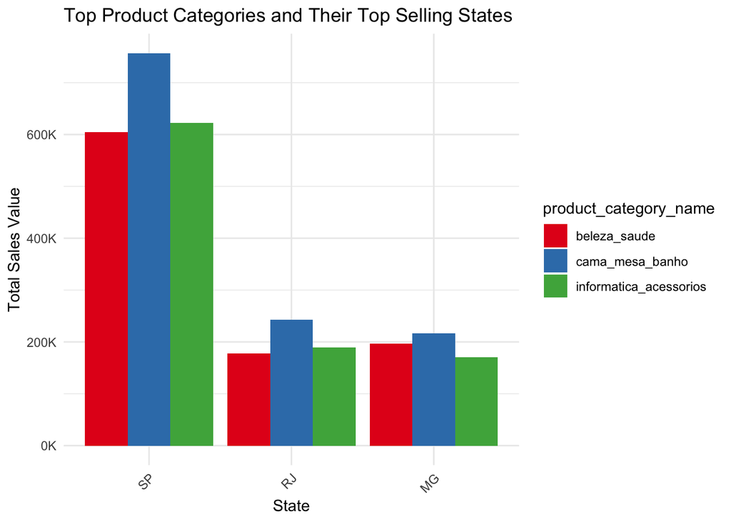

```r
library(ggplot2)  # ggplot2 kütüphanesini yükle (Load the ggplot2 library)
library(scales)   # label_number fonksiyonunu kullanmak için scales kütüphanesini yükle (Load the scales library to use the label_number function)

# En çok satan ürün kategorileri ve bunların en fazla satıldığı eyaletler için bar grafiği
# Bar plot for top product categories and their top selling states
ggplot(top_states_data, aes(x=reorder(customer_state, -payment_value), y=payment_value, fill=product_category_name)) +
  geom_bar(stat="identity", position="dodge") +  # Bar grafiği için verileri ekle (Add data to create a bar graph)
  labs(title="Top Product Categories and Their Top Selling States",  # Başlık ve eksen etiketlerini ayarla (Set the title and axis labels)
       x="State",
       y="Total Sales Value") +
  theme_minimal() +  # Minimal tema uygula (Apply a minimal theme)
  theme(axis.text.x = element_text(angle=45, hjust=1)) +  # X eksenindeki etiketleri döndür (Rotate the x-axis labels)
  scale_y_continuous(labels = label_number(scale = 1e-3, suffix = "K")) +  # Y eksenindeki etiketleri formatla (Format the y-axis labels to show in thousands (K))
  scale_fill_brewer(palette="Set1")  # Renk paletini değiştir (Change the color palette)
```

## **Buraya Kadar Neler yaptık - Let’s see what we have done so far?**

### 1. **Veri Temizleme ve Eksik Değerlerle İlgili İşlemler - Data Cleaning and Missing Value Handling**

- **Eksik verilerin doldurulması ve çıkarılması - Filling and removing missing values**:
  - `orders` ve `products` veri setlerindeki eksik değerler dolduruldu veya çıkarıldı. (Missing values in `orders` and `products` datasets were filled or removed.)
  - Özellikle **`order_approved_at`**, **`order_delivered_carrier_date`**, **`product_weight_g`**, **`product_category_name`** gibi sütunlardaki eksik değerlerle ilgili işlemler yapıldı. (We handled missing values in columns like `order_approved_at`, `order_delivered_carrier_date`, `product_weight_g`, and `product_category_name`.)

### 2. **Keşifsel Veri Analizi (Exploratory Data Analysis - EDA)**

- **Veri setlerinin genel istatistiksel incelemesi - General statistical exploration of datasets**:
  - Sipariş ve ödeme verileri incelendi. (Order and payment data were analyzed.)
- **Veri seti yapısının kontrolü - Checking the dataset structure**:
  - Her veri setinin yapısı ve sütun isimleri incelendi. (We examined the structure and column names of each dataset.)
- **Veri gruplama ve özet istatistikler - Data grouping and summary statistics**:
  - Ödeme yöntemlerinin dağılımı ve ürün kategorilerinin satış performansı analiz edildi. (We analyzed the distribution of payment methods and the sales performance of product categories.)

### 3. **A/B Testi (Welch T-Test) - A/B Testing (Welch T-Test)**

- **Farklı ödeme yöntemlerinin karşılaştırılması - Comparing different payment methods**:
  - **`payment_type_1`** ve **`payment_type_2`** arasında Welch Two Sample T-Test uygulandı. (Welch Two Sample T-Test was applied between `payment_type_1` and `payment_type_2`.)
  - Sonuçlar istatistiksel anlamlılık ile incelendi (p-value). (The results were examined for statistical significance (p-value).)

### 4. **Zaman Serisi Analizi (Time Series Analysis)**

- **Siparişlerin zaman içindeki dağılımı - Analyzing order trends over time**:
  - Aylara göre siparişlerin değişimi analiz edildi ve grafikle görselleştirildi. (The monthly change in orders was analyzed and visualized with a graph.)
- **Hafta içi ve hafta sonu siparişlerinin karşılaştırılması - Comparing weekday and weekend orders**:
  - Hafta içi ve hafta sonu yapılan alışveriş tutarlarının trendleri karşılaştırıldı ve haftalık sipariş dağılımı incelendi. (We compared shopping trends between weekdays and weekends, and analyzed weekly order distribution.)

## **Şimdi Zaman Serisi Tahmini Yapalım (Time Series Forecasting)**

- **Amaç:** Gelecekteki satışları tahmin etmek.(Purpose: To predict future sales.)
- **Yöntem:**(Method:) Zaman serisi analiziyle (örneğin ARIMA, Exponential Smoothing) geçmiş sipariş verilerini kullanarak gelecekteki sipariş hacmini tahmin edebilirsiniz.(With time series analysis (e.g. ARIMA, Exponential Smoothing) you can forecast future order volume using historical order data.)

Aylık veya haftalık bazda sipariş trendlerine bakarak kısa ve uzun vadeli tahminler yapılabilir. (Short and long-term forecasts can be made by looking at order trends on a monthly or weekly basis.)

- **Sonuçlar:**(Results:)

Talep tahmini ve stok yönetimi gibi konularda daha iyi kararlar verilebilir. (Better decisions can be made on issues such as demand forecasting and inventory management.)

```r
# Veriyi hazırlama ve zaman serisine uygun hale getirme (Prepare data for time series analysis)
# Sipariş tarihlerinin ay bazında gruplanması (Group orders by month)

library(dplyr)

# Tarihi 'Date' formatına çevir (Convert the date to 'Date' format)
final_merged_data$order_purchase_timestamp <- as.Date(final_merged_data$order_purchase_timestamp)

# Aylık sipariş sayısını hesapla (Calculate the number of orders per month)
monthly_orders <- final_merged_data %>%
  mutate(month = format(order_purchase_timestamp, "%Y-%m")) %>%  # Ay bilgisi ekle (Add month info)
  group_by(month) %>%
  summarise(total_orders = n())  # Toplam sipariş sayısını hesapla (Calculate total number of orders)

# Aylık siparişleri görüntüle (View monthly orders)
print(monthly_orders)
```

```
## # A tibble: 22 × 2
##    month   total_orders
##    <chr>          <int>
##  1 2016-10          334
##  2 2016-12            1
##  3 2017-01          951
##  4 2017-02         1905
##  5 2017-03         3014
##  6 2017-04         2631
##  7 2017-05         4162
##  8 2017-06         3628
##  9 2017-07         4655
## 10 2017-08         4974
## # ℹ 12 more rows
```

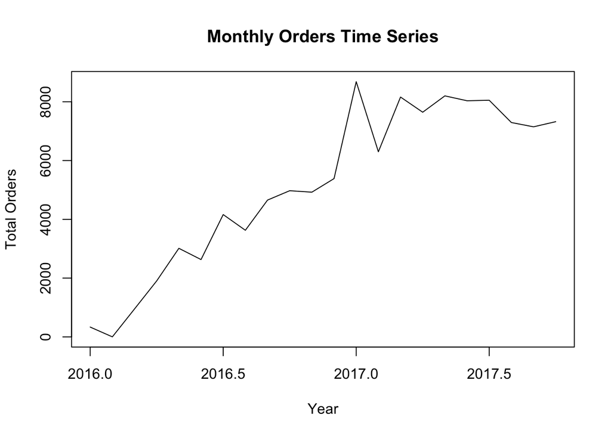

```r
# Zaman serisi oluşturma (Create time series data)
monthly_orders_ts <- ts(monthly_orders$total_orders, start = c(2016, 1), frequency = 12)  # Aylık frekanslı zaman serisi (Monthly frequency time series)

# Zaman serisini görselleştirme (Visualize time series)
plot(monthly_orders_ts, main="Monthly Orders Time Series", ylab="Total Orders", xlab="Year")
```

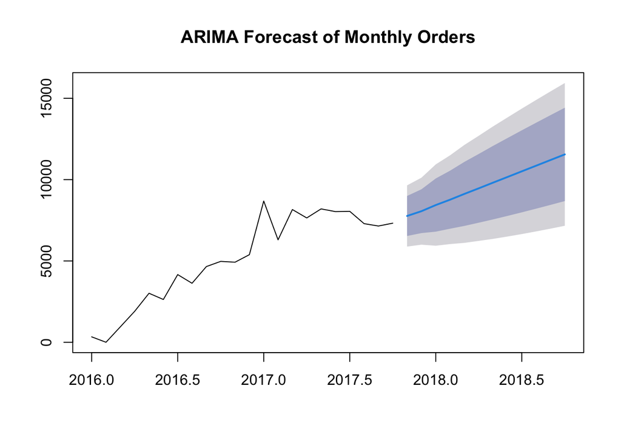

```r
library(forecast)  # Forecasting için gerekli kütüphane (Load library for forecasting)

# ARIMA modelini oluştur (Fit ARIMA model)
arima_model <- auto.arima(monthly_orders_ts)

# Tahmin yap (Make a forecast)
forecasted_orders <- forecast(arima_model, h=12)  # Önümüzdeki 12 ay için tahmin (Forecast for the next 12 months)

# Tahmini görselleştir (Visualize the forecast)
plot(forecasted_orders, main="ARIMA Forecast of Monthly Orders")
```

```r
# Modelin hata oranlarını görüntüle (View model's error metrics)
accuracy(arima_model)
```

```
##                     ME     RMSE      MAE       MPE     MAPE      MASE        ACF1
## Training set -11.97415 892.5092 611.5641 -2566.831 2582.648 0.1208959 -0.01327669
```

### ARIMA Model Performans Metriği - ARIMA Model Performance Metrics

Modelin doğruluğunu değerlendirmek için aşağıdaki hata metrikleri kullanılır. Bu metrikler, modelin tahmin ettiği değerler ile gerçek değerler arasındaki farkları ölçer. İşte her bir metriğin anlamı: (The following error metrics are used to evaluate the accuracy of the model. These metrics measure the differences between the values predicted by the model and the actual values. Here is what each metric means:)

1. **ME (Mean Error - Ortalama Hata)**:
   - Tahmin edilen değerlerle gerçek değerler arasındaki ortalama sapmadır. Eğer 0’a yakınsa, model genel olarak dengeli tahmin yapıyor demektir.
   - The average difference between the predicted and actual values. If it’s close to 0, the model is unbiased.
2. **RMSE (Root Mean Squared Error - Kök Ortalama Kare Hatası)**:
   - Hataların karelerinin ortalamasının kareköküdür. Hata miktarını ifade eder; düşük bir değer daha iyi bir model performansına işaret eder.
   - The square root of the average of squared errors. A lower value indicates a better model performance.
3. **MAE (Mean Absolute Error - Ortalama Mutlak Hata)**:
   - Gerçek değerlerle tahmin edilen değerler arasındaki mutlak farkların ortalamasıdır. Hata oranını verir; düşük olması istenir.
   - The average of absolute differences between actual and predicted values. Lower values indicate better performance.
4. **MPE (Mean Percentage Error - Ortalama Yüzde Hatası)**:
   - Gerçek değerlerle tahmin edilen değerler arasındaki yüzde farkının ortalamasıdır. Negatif ya da pozitif olabilir, modelin sapma yönünü gösterir.
   - The average percentage difference between actual and predicted values. Can be positive or negative, indicating model bias direction.
5. **MAPE (Mean Absolute Percentage Error - Ortalama Mutlak Yüzde Hatası)**:
   - Gerçek değerlerle tahmin edilen değerler arasındaki mutlak yüzde farkıdır. Daha düşük bir MAPE değeri daha iyi bir model performansı anlamına gelir.
   - The average of the absolute percentage differences between actual and predicted values. Lower MAPE indicates better accuracy.
6. **MASE (Mean Absolute Scaled Error - Ortalama Mutlak Ölçekli Hata)**:
   - Hataları ölçeklendirir ve karşılaştırma yapmayı sağlar. 1’den küçük değerler modelin iyi olduğunu gösterir.
   - Scales errors to allow for comparison. Values less than 1 indicate that the model is performing well.
7. **ACF1 (Autocorrelation at Lag 1 - Gecikme 1’de Otokorelasyon)**:
   - Tahmin hataları arasındaki otokorelasyon derecesini ölçer. 0’a yakın bir değer, model hatalarının rastgele olduğunu gösterir.
   - Measures the autocorrelation of forecast errors at lag 1. Values near 0 indicate that forecast errors are random.

### Nasıl Yorumlanmalı? - How to Interpret?

- **ME** değeri 0’a yakınsa, model tahminlerinde sistematik bir hata yapmıyor demektir. If the **ME** value is close to 0, the model does not make a systematic error in its predictions.
- **RMSE** ve **MAE** değerleri ne kadar düşükse, model o kadar doğru tahminler yapıyor demektir. The lower the **RMSE** and **MAE** values, the more accurate the predictions the model makes.
- **MPE** ve **MAPE** değerleri, modelin tahmin ettiği değerlerin ne kadar isabetli olduğunu yüzdesel olarak gösterir. **MPE** and **MAPE** values show how accurate the values predicted by the model are as a percentage.
- **MASE** değeri 1’den küçükse, model geçmiş ortalamalardan daha iyi tahmin yapıyor demektir. If the **MASE** value is less than 1, the model is making better predictions than historical averages.
- **ACF1** değeri 0’a ne kadar yakınsa, modelin hata tahminlerinin rastgele olduğunu ve modelin öngörü hatalarının bağımsız olduğunu gösterir. The closer the **ACF1** value is to 0, the more random the model’s error estimates are and the model’s prediction errors are independent.

Bu metrikler, modelin tahminlerinin ne kadar güvenilir olduğunu ve hangi alanlarda iyileştirme yapılması gerektiğini anlamak için kullanılır. These metrics are used to understand how reliable the model’s predictions are and where improvements are needed.

### ARIMA Model Performans Analizi - ARIMA Model Performance Analysis

ARIMA modelimizin çıktısını adım adım analiz edelim ve performansı hakkında yorum yapalım: Let’s analyze the output of our ARIMA model step by step and comment on its performance:

### Çıktı - Output:

| Metrik | Değer | Metric | Value |
| --- | --- | --- | --- |
| ME (Ortalama Hata) | -11.97415 | ME (Mean Error) | -11.97415 |
| RMSE (Kök Ortalama Kare Hatası) | 892.5092 | RMSE (Root Mean Squared Error) | 892.5092 |
| MAE (Ortalama Mutlak Hata) | 611.5641 | MAE (Mean Absolute Error) | 611.5641 |
| MPE (Ortalama Yüzde Hatası) | -2566.831 | MPE (Mean Percentage Error) | -2566.831 |
| MAPE (Ortalama Mutlak Yüzde Hatası) | 2582.648 | MAPE (Mean Absolute Percentage Error) | 2582.648 |
| MASE (Ortalama Mutlak Ölçekli Hata) | 0.1208959 | MASE (Mean Absolute Scaled Error) | 0.1208959 |
| ACF1 (Gecikme 1’de Otokorelasyon) | -0.01327669 | ACF1 (Autocorrelation at Lag 1) | -0.01327669 |

#### 2. **RMSE (Kök Ortalama Kare Hatası - Root Mean Squared Error)**:

- RMSE, tahmin hatalarının boyutunu gösterir. Modelin ortalama hatası 892.5 birimdir. Yani modelin tahminleri, gerçek değerlerden ortalama olarak bu kadar sapma gösteriyor.
- RMSE shows the size of the prediction errors. The model’s average error is 892.5 units, meaning the model’s predictions deviate by this much from actual values on average.

#### 3. **MAE (Ortalama Mutlak Hata - Mean Absolute Error)**:

- MAE, tahminlerin ortalama mutlak hatasını gösterir. Model, tahminlerinde ortalama olarak 611.5 birimlik sapma gösteriyor. RMSE ile karşılaştırıldığında, hata dağılımı küçük hatalarla sınırlı olabilir.
- MAE shows the average of the absolute errors. The model’s predictions deviate by 611.5 units on average. Compared to RMSE, the error distribution might be concentrated in smaller errors.

#### 5. **MAPE (Ortalama Mutlak Yüzde Hatası - Mean Absolute Percentage Error)**:

- MAPE değeri %2582 gibi oldukça yüksek bir değere sahip. Bu, modelin tahminlerinin gerçek değerlerden oldukça uzak olduğunu gösterir. Genellikle %10’un altındaki MAPE değeri iyi kabul edilir.
- MAPE has a very high value of 2582%, showing that the model’s predictions deviate substantially from actual values. Generally, MAPE below 10% is considered good.

#### 6. **MASE (Ortalama Mutlak Ölçekli Hata - Mean Absolute Scaled Error)**:

- MASE değeri 1’den çok daha küçük, bu da modelin genel olarak başarılı olduğunu gösteriyor. 1’den küçük bir MASE değeri, modelin sabit bir ortalamaya dayalı tahmine göre daha iyi performans gösterdiğini gösterir.
- A MASE value much smaller than 1 shows that the model is performing well overall. A MASE value less than 1 indicates the model is outperforming a naive forecast based on the mean.

#### 7. **ACF1 (Gecikme 1’de Otokorelasyon - Autocorrelation at Lag 1)**:

- ACF1 değeri neredeyse sıfıra yakın, bu da modelin tahmin hatalarının rastgele olduğunu ve bir kalıba bağlı olmadığını gösterir.
- The ACF1 value is near zero, indicating that the forecast errors are random and not following a specific pattern.

### İyileştirme Önerileri - Improvement Suggestions:

- Modeli daha iyi ayarlamak için zaman serisi üzerinde ek özellik mühendisliği yapılabilir. Alternatif modeller (Exponential Smoothing, Prophet gibi) ile karşılaştırma yaparak daha iyi sonuçlar elde edilebilir. To better tune the model, feature engineering on the time series can be done. Alternative models (such as Exponential Smoothing or Prophet) can be used for comparison to obtain better results.

### İyileştirme Çalışması - Improvment

- ARIMA modelinin performansını artırmak için alternatif bir model denemek en etkili stratejilerden biri olabilir. Exponential Smoothing, trend ve mevsimsellik içeren veri setlerinde güçlü tahminler yapabilme yeteneğine sahiptir. Trying an alternative model to improve the performance of the ARIMA model can be one of the most effective strategies. Exponential Smoothing has the ability to make strong predictions in data sets that contain trends and seasonality.
- Bu yöntemle, hem modelin basitliğini koruyarak hem de trend ve mevsimsellik bileşenlerini yakalayarak daha iyi tahminler yapabiliriz. Şimdi adım adım Exponential Smoothing modeli oluşturalım ve tahmin yapalım. With this method, we can make better predictions by keeping the model simple and capturing the trend and seasonality components. Now let’s create the Exponential Smoothing model step by step and make predictions.

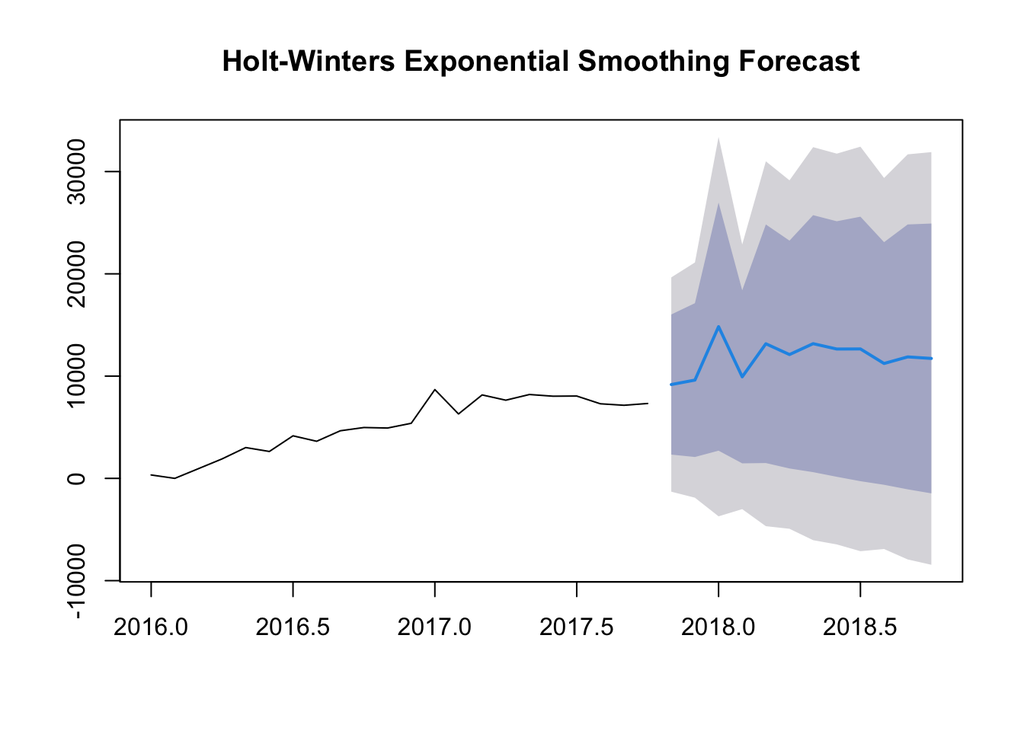

```r
library(forecast)  # Holt-Winters modeli için forecast kütüphanesini yükle (Load forecast library for Holt-Winters model)

# Holt-Winters Exponential Smoothing modelini oluştur (Fit Holt-Winters Exponential Smoothing model)
hw_model <- hw(monthly_orders_ts, seasonal="multiplicative")  # Mevsimsellik çarpımsal olarak ayarlandı (Seasonality set as multiplicative)

# Tahmin yap (Make a forecast)
hw_forecast <- forecast(hw_model, h=12)  # Önümüzdeki 12 ay için tahmin (Forecast for the next 12 months)

# Tahmini görselleştir (Visualize the forecast)
plot(hw_forecast, main="Holt-Winters Exponential Smoothing Forecast")
```

```r
# Modelin hata oranlarını görüntüle (View model's error metrics)
accuracy(hw_model)
```

```
##                     ME     RMSE      MAE       MPE     MAPE      MASE      ACF1
## Training set -85.19558 590.2868 517.0832 -3893.458 3905.301 0.1022186 0.5031757
```

```r
# ARIMA modelinin hata oranları (ARIMA model accuracy)
arima_accuracy <- accuracy(arima_model)
print("ARIMA Model Accuracy")
```

```
## [1] "ARIMA Model Accuracy"
```

```r
print(arima_accuracy)
```

```
##                     ME     RMSE      MAE       MPE     MAPE      MASE        ACF1
## Training set -11.97415 892.5092 611.5641 -2566.831 2582.648 0.1208959 -0.01327669
```

```r
# Holt-Winters modelinin hata oranları (Holt-Winters model accuracy)
hw_accuracy <- accuracy(hw_model)
print("Holt-Winters Model Accuracy")
```

```
## [1] "Holt-Winters Model Accuracy"
```

```r
print(hw_accuracy)
```

```
##                     ME     RMSE      MAE       MPE     MAPE      MASE      ACF1
## Training set -85.19558 590.2868 517.0832 -3893.458 3905.301 0.1022186 0.5031757
```

```r
# Modelleri karşılaştırma (Compare the models)
comparison <- data.frame(
  Model = c("ARIMA", "Holt-Winters"),
  RMSE = c(arima_accuracy[2], hw_accuracy[2]),
  MAE = c(arima_accuracy[3], hw_accuracy[3]),
  MASE = c(arima_accuracy[6], hw_accuracy[6])
)

print("Comparison of ARIMA and Holt-Winters Models")
```

```
## [1] "Comparison of ARIMA and Holt-Winters Models"
```

```r
print(comparison)
```

```
##          Model     RMSE      MAE      MASE
## 1        ARIMA 892.5092 611.5641 0.1208959
## 2 Holt-Winters 590.2868 517.0832 0.1022186
```

### Performans Yorumlaması - Performance Interpretation:

#### ARIMA Modeli:

- **RMSE (Root Mean Squared Error)**: **892.5092**
- **MAE (Mean Absolute Error)**: **611.5641**
- **MASE (Mean Absolute Scaled Error)**: **0.1208959**

#### Holt-Winters Modeli:

- **RMSE (Root Mean Squared Error)**: **590.2868**
- **MAE (Mean Absolute Error)**: **517.0832**
- **MASE (Mean Absolute Scaled Error)**: **0.1022186**

### Performans Yorumlaması:

1. **RMSE (Kök Ortalama Kare Hatası)**:
   - **Holt-Winters** modelinin RMSE değeri (**590.2868**) **ARIMA** modelinden daha düşük (**892.5092**). Bu, Holt-Winters modelinin tahminlerinde daha az hata yaptığını gösterir.
   - **Yorum**: **Holt-Winters** modeli, zaman serisindeki verileri daha iyi yakalıyor ve daha az sapma ile tahmin yapıyor.
2. **MAE (Ortalama Mutlak Hata)**:
   - **Holt-Winters** modelinin MAE değeri (**517.0832**), **ARIMA** modelinden daha düşük (**611.5641**). Bu, Holt-Winters modelinin ortalama hata oranının daha düşük olduğunu ve daha iyi bir tahmin gücüne sahip olduğunu gösterir.
   - **Yorum**: **Holt-Winters** modeli, genel olarak tahmin ettiği değerlerin gerçek değerlere daha yakın olduğunu gösteriyor.
3. **MASE (Ortalama Mutlak Ölçekli Hata)**:
   - **Holt-Winters** modelinin MASE değeri (**0.1022186**), **ARIMA** modeline göre daha küçük (**0.1208959**). Bu da Holt-Winters modelinin hata oranının ölçeklendirilmiş veri üzerinde daha iyi olduğunu gösteriyor.
   - **Yorum**: **MASE** değerlerinin her iki modelde de 1’den küçük olması, her iki modelin de makul performans gösterdiğini, ancak **Holt-Winters** modelinin daha üstün olduğunu gösterir.

### Bir Sonraki Adım:

- Bu modelin tahminlerini kullanarak **iş kararları** verebilir ve stok yönetimi, talep tahmini gibi alanlarda daha sağlam planlar yapabilirsiniz. Ayrıca, bu modelle birlikte zaman serisi verisinde daha ayrıntılı analizler de yapabiliriz.
- You can use the forecasts from this model to make **business decisions**, like inventory management and demand forecasting. We can also do more detailed analyses on the time series data with this model.

### Devam Ediyoruz.. We continue..

### Sepet Analizi Adımları - Market Basket Analysis Steps:

1. **Veri Hazırlığı - Data Preparation**:
   - İlgili ürün ve sipariş verilerini temizleyip yapılandıracağız.
   - We will clean and structure the relevant product and order data.
2. **Birliktelik Kuralları (Association Rules)**:
   - Hangi ürünlerin birlikte satın alındığını belirlemek için Apriori algoritmasını uygulayacağız.
   - We will apply the Apriori algorithm to identify which products are frequently purchased together.
3. **Sonuçları Görselleştirme - Visualizing Results**:
   - En sık birlikte satın alınan ürün çiftlerini görselleştireceğiz.
   - We will visualize the most frequently co-purchased product pairs.

```r
# Gerekli kütüphaneleri yükleyelim (Load required libraries)
library(arules)         # Birliktelik kuralları için (For association rules)
library(arulesViz)      # Birliktelik kuralları görselleştirme için (For visualizing association rules)

# Sepet analizi için gerekli veriyi hazırlama (Prepare data for Market Basket Analysis)
# order_items veri setini kullanarak her siparişteki ürünleri listeleyelim (Use the order_items dataset to list products per order)
orders_products <- split(final_merged_data$product_category_name, final_merged_data$order_id)

# Veriyi arules paketi için transactions formatına dönüştürelim (Convert data to transactions format for arules package)
transactions <- as(orders_products, "transactions")
# İlk 10 transaction'ı inceleyelim (Inspect the first 10 transactions)
inspect(transactions[1:10])
```

```
##      items                   transactionID
## [1]  {cool_stuff}            00010242fe8c5a6d1ba2dd792cb16214
## [2]  {pet_shop}              00018f77f2f0320c557190d7a144bdd3
## [3]  {moveis_decoracao}      000229ec398224ef6ca0657da4fc703e
## [4]  {perfumaria}            00024acbcdf0a6daa1e931b038114c75
## [5]  {ferramentas_jardim}    00042b26cf59d7ce69dfabb4e55b4fd9
## [6]  {utilidades_domesticas} 00048cc3ae777c65dbb7d2a0634bc1ea
## [7]  {telefonia}             00054e8431b9d7675808bcb819fb4a32
## [8]  {ferramentas_jardim}    000576fe39319847cbb9d288c5617fa6
## [9]  {beleza_saude}          0005a1a1728c9d785b8e2b08b904576c
## [10] {livros_tecnicos}       0005f50442cb953dcd1d21e1fb923495
```

```r
# Transaction nesnesini kontrol etme (Check the transactions object)
summary(transactions)
```

```
## transactions as itemMatrix in sparse format with
##  95143 rows (elements/itemsets/transactions) and
##  73 columns (items) and a density of 0.01380503
##
## most frequent items:
##        cama_mesa_banho           beleza_saude          esporte_lazer informatica_acessorios
##                   9272                   8648                   7530                   6529
##       moveis_decoracao                (Other)
##                   6307                  57596
##
## element (itemset/transaction) length distribution:
## sizes
##     1     2     3
## 94419   709    15
##
##    Min. 1st Qu.  Median    Mean 3rd Qu.    Max.
##   1.000   1.000   1.000   1.008   1.000   3.000
##
## includes extended item information - examples:
##                      labels
## 1 agro_industria_e_comercio
## 2                 alimentos
## 3         alimentos_bebidas
##
## includes extended transaction information - examples:
##                      transactionID
## 1 00010242fe8c5a6d1ba2dd792cb16214
## 2 00018f77f2f0320c557190d7a144bdd3
## 3 000229ec398224ef6ca0657da4fc703e
```

### Veriyi İnceleme ve Yorum - Data Examination and Interpretation:

#### 1. Verinin Özeti - Data Summary (transactions as itemMatrix):

- **95143** satır (transactions) ve **73** ürün kategorisi (items) mevcut.
- Verinin yoğunluğu oldukça düşük (%1.38), bu da veri setindeki çoğu işlemin (transaction) yalnızca bir veya iki ürün içerdiğini gösteriyor.
- En sık satın alınan ürün kategorileri: **cama_mesa_banho** (9272 işlem), **beleza_saude** (8648 işlem), **esporte_lazer** (7530 işlem).
- **95143** rows (transactions) and **73** product categories (items) exist.
- The data density is quite low (1.38%), which indicates that most transactions only contain one or two products.
- Most frequently purchased product categories: **cama_mesa_banho** (9272 transactions), **beleza_saude** (8648 transactions), **esporte_lazer** (7530 transactions).

#### 2. Element (itemset/transaction) Uzunluğu Dağılımı - Element Length Distribution:

- Çoğu işlem yalnızca 1 üründen oluşuyor (94419 adet). Sadece **709** işlem 2 üründen oluşurken, 3 ürün içeren sadece **15** işlem var.
- Most transactions contain only 1 item (94419 transactions). Only **709** transactions have 2 items, while just **15** transactions have 3 items.

#### Yorum - Interpretation:

- **Birlikte satın alma** analizi yapabilmek için işlem başına daha fazla ürünün olduğu veri setlerinde daha iyi sonuçlar alınır. Ancak burada çoğu işlem tek ürün içeriyor. Bu nedenle, çok fazla birliktelik kuralı çıkmayabilir.
- To perform **market basket analysis**, it is generally better if transactions contain more products. However, since most transactions here have only one product, we may not get many association rules.
- Yine de destek ve güven oranlarını azaltarak bazı kural elde etmeye çalışabiliriz.
- However, we can still try reducing the support and confidence thresholds to generate some rules.

### Bir sonraki adım - Next Step:

Veriyi bu haliyle işleyelim ve **Apriori algoritmasını** daha düşük destek (support) ve güven (confidence) değerleriyle çalıştırarak kural oluşturalım.

Let’s proceed with processing the data as it is and run the **Apriori algorithm** with lower support and confidence values to generate rules.

### Gelen çıktıya göre;

```r
# Apriori algoritmasını daha düşük parametrelerle çalıştırma (Run Apriori with even lower support and confidence)
rules <- apriori(transactions, parameter = list(supp = 0.00001, conf = 0.2, minlen = 2))
```

```
## Apriori
##
## Parameter specification:
##  confidence minval smax arem  aval originalSupport maxtime support minlen maxlen target  ext
##         0.2    0.1    1 none FALSE            TRUE       5   1e-05      2     10  rules TRUE
##
## Algorithmic control:
##  filter tree heap memopt load sort verbose
##     0.1 TRUE TRUE  FALSE TRUE    2    TRUE
##
## Absolute minimum support count: 0
##
## set item appearances ...[0 item(s)] done [0.00s].
## set transactions ...[73 item(s), 95143 transaction(s)] done [0.02s].
## sorting and recoding items ... [73 item(s)] done [0.00s].
## creating transaction tree ... done [0.03s].
## checking subsets of size 1 2 3 done [0.00s].
## writing ... [26 rule(s)] done [0.00s].
## creating S4 object  ... done [0.01s].
```

```r
# Oluşturulan kural sayısını kontrol et (Check how many rules are generated)
length(rules)
```

```
## [1] 26
```

```r
# İlk birkaç kuralı görüntüle (View the first few rules)
inspect(rules[1:10])
```

```
##      lhs                                     rhs                                      support confidence     coverage      lift count
## [1]  {fashion_roupa_infanto_juvenil}      => {fashion_bolsas_e_acessorios}       2.102099e-05  0.2857143 7.357346e-05  14.92790     2
## [2]  {cine_foto,
##       cool_stuff}                         => {telefonia}                         1.051049e-05  1.0000000 1.051049e-05  23.24530     1
## [3]  {cine_foto,
##       telefonia}                          => {cool_stuff}                        1.051049e-05  1.0000000 1.051049e-05  26.73307     1
## [4]  {construcao_ferramentas_iluminacao,
##       ferramentas_jardim}                 => {cama_mesa_banho}                   1.051049e-05  1.0000000 1.051049e-05  10.26132     1
## [5]  {cama_mesa_banho,
##       construcao_ferramentas_iluminacao}  => {ferramentas_jardim}                1.051049e-05  1.0000000 1.051049e-05  27.59368     1
## [6]  {cama_mesa_banho,
##       ferramentas_jardim}                 => {construcao_ferramentas_iluminacao} 1.051049e-05  0.2500000 4.204198e-05  98.28822     1
## [7]  {market_place,
##       perfumaria}                         => {cama_mesa_banho}                   1.051049e-05  1.0000000 1.051049e-05  10.26132     1
## [8]  {cama_mesa_banho,
##       market_place}                       => {perfumaria}                        1.051049e-05  0.5000000 2.102099e-05  15.40528     1
## [9]  {cama_mesa_banho,
##       perfumaria}                         => {market_place}                      1.051049e-05  1.0000000 1.051049e-05 347.23723     1
## [10] {casa_construcao,
##       cool_stuff}                         => {informatica_acessorios}            1.051049e-05  1.0000000 1.051049e-05  14.57237     1
```

### Örnek

- Yukarıdaki kurallardan örneğin **fashion****_****roupa_infanto_juvenil** => **fashion_bolsas_e_acessorios**. **support: 0.00002102, confidence: 0.2857, lift: 14.92** kuralını elealalım: (For example, let’s take the rule **fashion****_****roupa_infanto_juvenil** => **fashion_bolsas_e_acessorios**. **support: 0.00002102, confidence: 0.2857, lift: 14.92** from the above rules:)
- **Bu kural**, fashion_roupa_infanto_juvenil kategorisinde bir ürün satın alındığında, fashion_bolsas_e_acessorios kategorisinde bir ürün satın alınma olasılığının **%28.57** olduğunu ve bu iki ürünün birlikte satın alınma oranının bağımsız satın almaya göre **14.92** kat daha fazla olduğunu gösteriyor.(**This rule** shows that when a product in the fashion_roupa_infanto_juvenil category is purchased, the probability of purchasing a product in the fashion_bolsas_e_acessorios category is **28.57%**, and the odds of purchasing these two products together are **14.92** times higher than purchasing them separately.)

[output not shown]

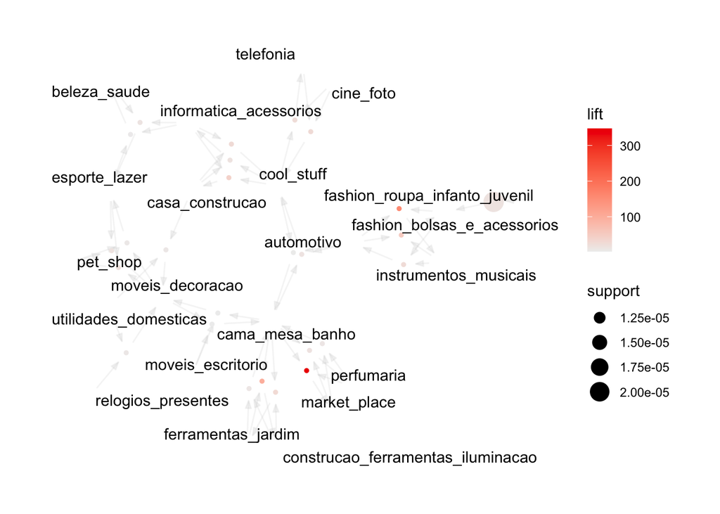

```r
# Birliktelik kurallarını görselleştirme (Visualize the association rules)
plot(rules, method = "graph", control = list(type = "items"))
```